# Bank Marketing

## Bank Marketing

The dataset is from marketing campaigns (phone calls) of Portuguese banking institution inviting clients to subscribe to a product service (bank term deposit). The answers are either a 'yes' or 'no' from customers. Some clients were contacted twice in order to access if they will subscribe. The dataset is from UCI dataset repository

The goal of this dataset and classification is to predict if a client will subscribe (yes) or not (no) to the term deposit (y variable)

```python
from ucimlrepo import fetch_ucirepo
import pandas as pd
import numpy as np
import matplotlib.pyplot as plt
import seaborn as sns

try:
    bank_marketing = fetch_ucirepo(id=222)

    X = bank_marketing.data.features
    y = bank_marketing.data.targets

    df = pd.concat([X, y], axis=1)
except ConnectionError:
    df = pd.read_csv('bank-full.csv', sep=';', na_values='unknown')
df.head()
```

|  | age | job | marital | education | default | balance | housing | loan | contact | day_of_week | month | duration | campaign | pdays | previous | poutcome | y |
| --- | --- | --- | --- | --- | --- | --- | --- | --- | --- | --- | --- | --- | --- | --- | --- | --- | --- |
| 0 | 58 | management | married | tertiary | no | 2143 | yes | no | NaN | 5 | may | 261 | 1 | -1 | 0 | NaN | no |
| 1 | 44 | technician | single | secondary | no | 29 | yes | no | NaN | 5 | may | 151 | 1 | -1 | 0 | NaN | no |
| 2 | 33 | entrepreneur | married | secondary | no | 2 | yes | yes | NaN | 5 | may | 76 | 1 | -1 | 0 | NaN | no |
| 3 | 47 | blue-collar | married | NaN | no | 1506 | yes | no | NaN | 5 | may | 92 | 1 | -1 | 0 | NaN | no |
| 4 | 33 | NaN | single | NaN | no | 1 | no | no | NaN | 5 | may | 198 | 1 | -1 | 0 | NaN | no |

```python
for col in df.columns:
    if col == 'day_of_week':
        df.rename(columns={col:'day'}, inplace=True)
```

```python
## Displaying variable descriptions
if 'bank_marketing' in globals():
    y_true = y
    display(bank_marketing.variables)
```

|  | name | role | type | demographic | description | units | missing_values |
| --- | --- | --- | --- | --- | --- | --- | --- |
| 0 | age | Feature | Integer | Age | None | None | no |
| 1 | job | Feature | Categorical | Occupation | type of job (categorical: 'admin.','blue-colla... | None | no |
| 2 | marital | Feature | Categorical | Marital Status | marital status (categorical: 'divorced','marri... | None | no |
| 3 | education | Feature | Categorical | Education Level | (categorical: 'basic.4y','basic.6y','basic.9y'... | None | no |
| 4 | default | Feature | Binary | None | has credit in default? | None | no |
| 5 | balance | Feature | Integer | None | average yearly balance | euros | no |
| 6 | housing | Feature | Binary | None | has housing loan? | None | no |
| 7 | loan | Feature | Binary | None | has personal loan? | None | no |
| 8 | contact | Feature | Categorical | None | contact communication type (categorical: 'cell... | None | yes |
| 9 | day_of_week | Feature | Date | None | last contact day of the week | None | no |
| 10 | month | Feature | Date | None | last contact month of year (categorical: 'jan'... | None | no |
| 11 | duration | Feature | Integer | None | last contact duration, in seconds (numeric). ... | None | no |
| 12 | campaign | Feature | Integer | None | number of contacts performed during this campa... | None | no |
| 13 | pdays | Feature | Integer | None | number of days that passed by after the client... | None | yes |
| 14 | previous | Feature | Integer | None | number of contacts performed before this campa... | None | no |
| 15 | poutcome | Feature | Categorical | None | outcome of the previous marketing campaign (ca... | None | yes |
| 16 | y | Target | Binary | None | has the client subscribed a term deposit? | None | no |

### EDA

Gaining insights from the data

```python
# summary statistics
df.describe()
```

|  | age | balance | day | duration | campaign | pdays | previous |
| --- | --- | --- | --- | --- | --- | --- | --- |
| count | 45211.000000 | 45211.000000 | 45211.000000 | 45211.000000 | 45211.000000 | 45211.000000 | 45211.000000 |
| mean | 40.936210 | 1362.272058 | 15.806419 | 258.163080 | 2.763841 | 40.197828 | 0.580323 |
| std | 10.618762 | 3044.765829 | 8.322476 | 257.527812 | 3.098021 | 100.128746 | 2.303441 |
| min | 18.000000 | -8019.000000 | 1.000000 | 0.000000 | 1.000000 | -1.000000 | 0.000000 |
| 25% | 33.000000 | 72.000000 | 8.000000 | 103.000000 | 1.000000 | -1.000000 | 0.000000 |
| 50% | 39.000000 | 448.000000 | 16.000000 | 180.000000 | 2.000000 | -1.000000 | 0.000000 |
| 75% | 48.000000 | 1428.000000 | 21.000000 | 319.000000 | 3.000000 | -1.000000 | 0.000000 |
| max | 95.000000 | 102127.000000 | 31.000000 | 4918.000000 | 63.000000 | 871.000000 | 275.000000 |

```python
# data information
df.info()
```

```
<class 'pandas.core.frame.DataFrame'>
RangeIndex: 45211 entries, 0 to 45210
Data columns (total 17 columns):
 #   Column     Non-Null Count  Dtype
---  ------     --------------  -----
 0   age        45211 non-null  int64
 1   job        44923 non-null  object
 2   marital    45211 non-null  object
 3   education  43354 non-null  object
 4   default    45211 non-null  object
 5   balance    45211 non-null  int64
 6   housing    45211 non-null  object
 7   loan       45211 non-null  object
 8   contact    32191 non-null  object
 9   day        45211 non-null  int64
 10  month      45211 non-null  object
 11  duration   45211 non-null  int64
 12  campaign   45211 non-null  int64
 13  pdays      45211 non-null  int64
 14  previous   45211 non-null  int64
 15  poutcome   8252 non-null   object
 16  y          45211 non-null  object
dtypes: int64(7), object(10)
memory usage: 5.9+ MB
```

```python
y.value_counts()
```

```
y
no     39922
yes     5289
Name: count, dtype: int64
```

```python
## Violin plot for numerical variables
plt.rc('axes',
       labelcolor='0.40',
       labelsize=8,
       labelweight='normal',
       titlecolor='0.25',
       titlesize=12,
       titleweight='bold',
      )

plt.rc('figure',
       labelsize=8,
       labelweight='normal',
       titlesize=12,
       titleweight='bold',
      )

sns.set_theme()
```

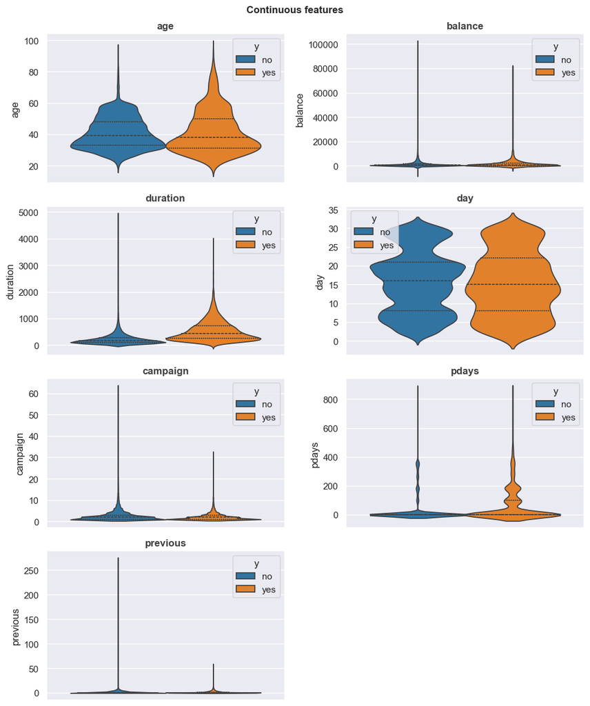

```python
# Visualizing the distribution of continuous and numerical variables
numerics = ['age', 'balance', 'duration', 'day', 'campaign', 'pdays', 'previous']

fig= plt.figure(figsize=[10, 12], layout='tight')
plt.suptitle('Continuous features')
for i in range(len(numerics)):
    ax = plt.subplot(4, 2, i+1)
    sns.violinplot(data=df,
                   y=numerics[i],
                   hue='y',
                   inner='quart',
                   palette='tab10',
                   #saturation=0.1,
                   ax=ax)
    ax.set_title(numerics[i])

plt.show()
```

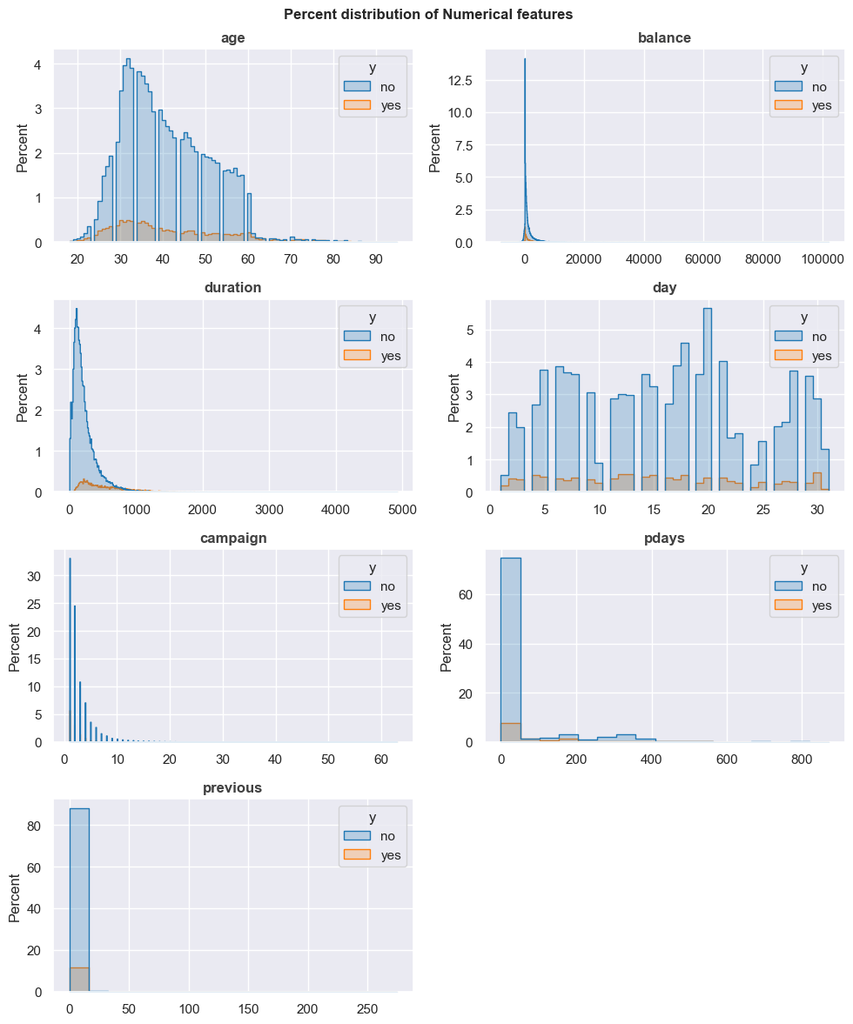

```python
#Histogram distribution of numerical features

fig= plt.figure(figsize=[10, 12], layout='tight')
plt.suptitle('Percent distribution of Numerical features')
for i in range(len(numerics)):
    ax = plt.subplot(4, 2, i+1)
    sns.histplot(data=df,
                   x=numerics[i],
                   hue='y', element='step',
                   palette='tab10',
                   stat='percent',
                   ax=ax)
    ax.set_title(numerics[i])
    ax.set_xlabel('')

plt.show()
```

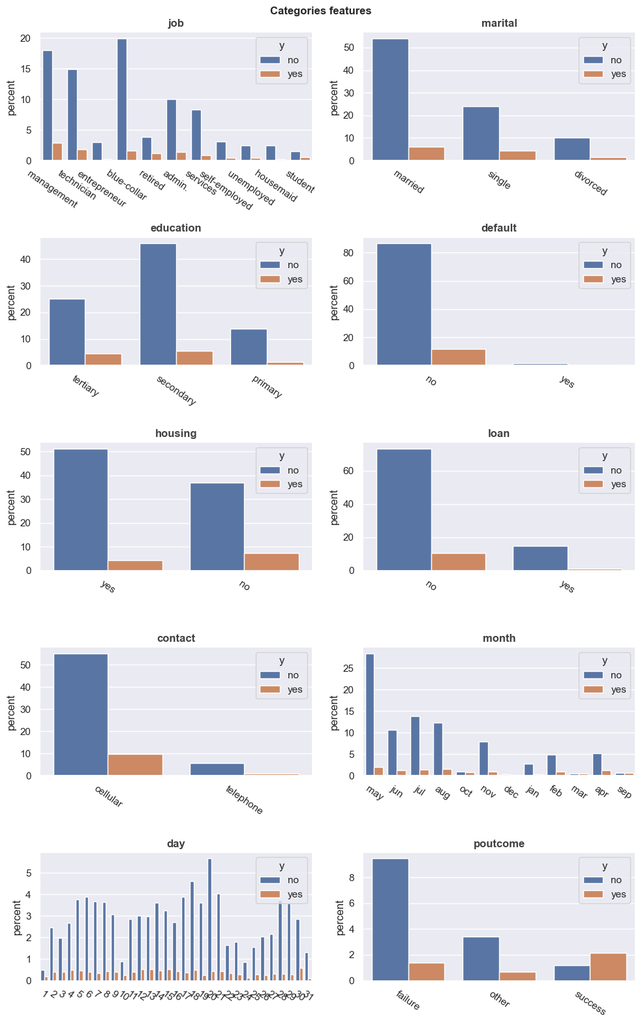

```python
# Visualising categorical features
categorical_features = ['job', 'marital', 'education', 'default', 'housing',
                        'loan', 'contact', 'month', 'day', 'poutcome']

fig = plt.figure(figsize=[10, 16], layout='tight')
plt.suptitle('Categories features')
for num, value in enumerate(categorical_features):
    ax = plt.subplot(5, 2, num+1)
    sns.countplot(data=df, x=value,
                hue='y',
                stat='percent')
    ax.set_title(value)
    ax.tick_params(axis='x', which='major',rotation=325)
    ax.set_xlabel('')

plt.show()
```

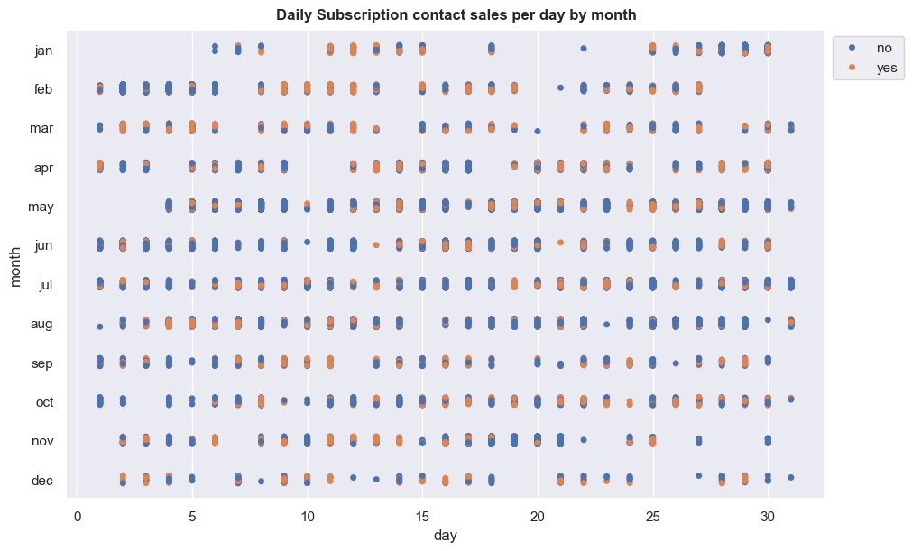

```python
# frequency of monthly contact made to clients
order=['jan', 'feb', 'mar', 'apr', 'may',
       'jun', 'jul', 'aug', 'sep', 'oct',
       'nov', 'dec']

plt.figure(figsize=[10, 6], layout='constrained')
plt.suptitle('Daily Subscription contact sales per day by month')

sns.stripplot(data=df, x='day', y='month', hue='y', jitter=True,
             order=order)
plt.legend(loc='best', bbox_to_anchor=(1,0,0, 1))
plt.show()
```

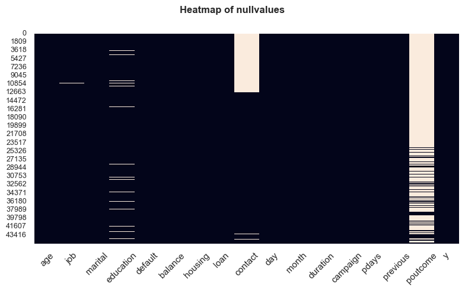

```python
## heatmap of null variables
plt.figure(figsize=(8,5), layout='tight')
plt.suptitle('Heatmap of nullvalues')

sns.heatmap(df.isnull(),
            cbar=False)
plt.xticks(rotation=45)
plt.yticks(fontsize=9)
plt.show()
```

##### summary

1. The first obvious information from the EDA is that percentage of success (yes response) from the marketing campaign is relatively of low percentage to the total contacts made by the bank. Therefore the overall distribution of the data is highly skewed to the right.
2. There are a number of possible outliers in the numerical variables based on the violin plots and these shall be investigated
3. The age distribution of most contacts made are between 25 to 60 years which fall under the age of working population.
4. An important thing to note about the duration of the call is that this feature can have a direct determination on the target (y) because a duration of 0 seconds will automatically mean a `no` outcome. However, there is no way of knowing the duration of a call and the outcome until the call has been made. So this data will only be available after y has been determined. Therefore this feature will not be taken forward for modelling.
5. On the categorical features, one of the things that stood out was that most contacts are made via cellular phone more than telephone which reflects the most common present means of communication
6. Also, you would see that there is a significant increase in the number of contacts made between `May` and `August`. This period is the summer period and then there is another sharp rise in `November` which reflects the month before the end of the year when companies also try the last push to meet their targets. There is minial contact made in December.
7. Finally, there are some columns with missing data as shown from the heatmap plot with 'poutcome' column having the most missing data among all other features.

### Outlier Investigations

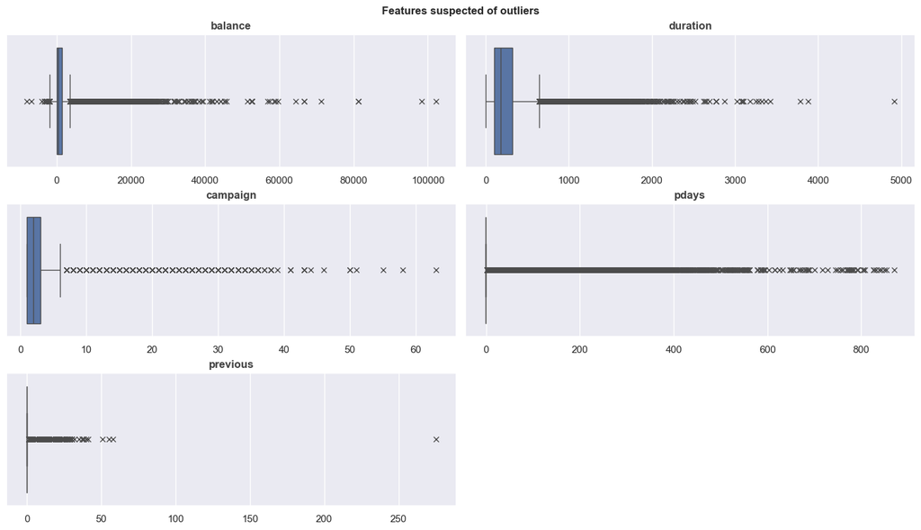

```python
# Visualising columns with suspected outliers
outlier_features = ['balance', 'duration',
                    'campaign', 'pdays',
                    'previous']

fig = plt.figure(figsize=(14, 8), layout='constrained')
plt.suptitle('Features suspected of outliers')
for num, feature in enumerate(outlier_features):
    ax = plt.subplot(3, 2, num+1)
    sns.boxplot(data=df, x=feature,
                ax=ax,
                flierprops={'marker':'x'},
    )
    ax.set_title(feature)
    ax.set_xlabel('')

plt.show()
```

#### Understanding the Balance column

```python
## Understanding high balance outliers
high_bal = df['balance'] > 60000

df[high_bal]
```

|  | age | job | marital | education | default | balance | housing | loan | contact | day | month | duration | campaign | pdays | previous | poutcome | y |
| --- | --- | --- | --- | --- | --- | --- | --- | --- | --- | --- | --- | --- | --- | --- | --- | --- | --- |
| 19420 | 59 | admin. | married | NaN | no | 64343 | no | no | cellular | 6 | aug | 45 | 4 | -1 | 0 | NaN | no |
| 19785 | 56 | management | divorced | tertiary | no | 66721 | no | no | cellular | 8 | aug | 442 | 2 | -1 | 0 | NaN | no |
| 21192 | 52 | blue-collar | married | primary | no | 66653 | no | no | cellular | 14 | aug | 109 | 3 | -1 | 0 | NaN | no |
| 26227 | 59 | management | married | tertiary | no | 98417 | no | no | telephone | 20 | nov | 145 | 5 | -1 | 0 | NaN | no |
| 39989 | 51 | management | single | tertiary | no | 102127 | no | no | cellular | 3 | jun | 90 | 1 | -1 | 0 | NaN | no |
| 41693 | 60 | retired | married | primary | no | 71188 | no | no | cellular | 6 | oct | 205 | 1 | -1 | 0 | NaN | no |
| 42558 | 84 | retired | married | secondary | no | 81204 | no | no | telephone | 28 | dec | 679 | 1 | 313 | 2 | other | yes |
| 43393 | 84 | retired | married | secondary | no | 81204 | no | no | telephone | 1 | apr | 390 | 1 | 94 | 3 | success | yes |

Looking at the dataset where balance is greater than 60,000, it makes sense to conclude that these numbers are not errors, none of the rows have credit defaults, housing loan or personal loan. The row with the highest balance, also shows the job as management, single and tertiary education with no credit defaults. Similar interpretations for the rest of the rows. The row with 71188 balance shows primary eductication but then, the job shows retired and married.

```python
## investigating balance between 40k and 60k
bal_40_60k = (df['balance'] > 40000) & (df['balance'] < 60000)
df[bal_40_60k]
```

|  | age | job | marital | education | default | balance | housing | loan | contact | day | month | duration | campaign | pdays | previous | poutcome | y |
| --- | --- | --- | --- | --- | --- | --- | --- | --- | --- | --- | --- | --- | --- | --- | --- | --- | --- |
| 446 | 39 | technician | single | NaN | no | 45248 | yes | no | NaN | 6 | may | 1623 | 1 | -1 | 0 | NaN | yes |
| 920 | 44 | admin. | married | secondary | no | 58544 | yes | no | NaN | 7 | may | 144 | 2 | -1 | 0 | NaN | no |
| 3197 | 43 | admin. | single | secondary | no | 56831 | no | no | NaN | 15 | may | 243 | 1 | -1 | 0 | NaN | no |
| 9425 | 59 | housemaid | divorced | secondary | no | 45141 | no | no | NaN | 6 | jun | 42 | 1 | -1 | 0 | NaN | no |
| 9536 | 58 | entrepreneur | married | primary | no | 52499 | no | no | NaN | 6 | jun | 198 | 2 | -1 | 0 | NaN | no |
| 12926 | 56 | blue-collar | married | secondary | no | 58932 | no | no | telephone | 7 | jul | 339 | 2 | -1 | 0 | NaN | no |
| 13154 | 56 | entrepreneur | married | tertiary | no | 51439 | no | yes | cellular | 8 | jul | 325 | 1 | -1 | 0 | NaN | no |
| 15869 | 38 | admin. | single | tertiary | no | 45789 | no | no | telephone | 21 | jul | 21 | 31 | -1 | 0 | NaN | no |
| 19410 | 55 | entrepreneur | married | tertiary | no | 41923 | no | no | cellular | 6 | aug | 69 | 3 | -1 | 0 | NaN | no |
| 19795 | 42 | entrepreneur | married | tertiary | no | 42045 | no | no | cellular | 8 | aug | 205 | 2 | -1 | 0 | NaN | no |
| 21346 | 43 | management | married | tertiary | no | 41630 | no | no | cellular | 18 | aug | 68 | 4 | -1 | 0 | NaN | no |
| 22091 | 40 | management | married | tertiary | no | 52527 | no | no | cellular | 21 | aug | 140 | 11 | -1 | 0 | NaN | no |
| 22765 | 55 | management | single | tertiary | no | 43074 | yes | no | cellular | 25 | aug | 92 | 6 | -1 | 0 | NaN | no |
| 27049 | 31 | management | single | tertiary | no | 44128 | no | no | cellular | 21 | nov | 74 | 1 | -1 | 0 | NaN | no |
| 27090 | 59 | retired | married | tertiary | no | 41242 | no | no | cellular | 21 | nov | 161 | 1 | -1 | 0 | NaN | no |
| 27390 | 50 | services | married | secondary | no | 57435 | yes | no | cellular | 21 | nov | 319 | 3 | -1 | 0 | NaN | no |
| 29512 | 59 | unemployed | divorced | secondary | no | 44134 | no | no | cellular | 3 | feb | 117 | 1 | -1 | 0 | NaN | no |
| 40763 | 61 | self-employed | divorced | tertiary | no | 52587 | no | no | cellular | 10 | aug | 290 | 1 | -1 | 0 | NaN | yes |
| 41374 | 32 | entrepreneur | single | tertiary | no | 59649 | no | no | cellular | 1 | sep | 69 | 2 | -1 | 0 | NaN | no |
| 43053 | 61 | self-employed | divorced | tertiary | no | 52587 | no | no | cellular | 15 | feb | 394 | 3 | 189 | 1 | success | yes |

Again, looking at the dataset for balance between 40k to 60k, there is no credit defaults and the data would make sense for the balance. The only rows that stood out are:

1. The 'technician' but its listed as single and at the age of 39 with housing loan. but its not impossible with the job not to have such balance
2. The 'housemaid' row, however, it's listed as divorced and at the age of 59 which makes it possible with no loans
3. The row numbe 27049 with the age of 31. but if the candidate is single with a management job, you could expect such a balance without loans
4. The row listed as unemployed also is divorced and at the age of 59 with no loans is justified
5. finally, row 41374 with age of 32 is listed as entrepreneur with tertiary education and single which is justified.

```python
## Balance below zero will be looked at in two ways. The first are those with <0 balance and with housing or personal loan
## the second are those wiht low balance without housing or personal loan.
#### The FIRST
# because there a large number of rows with less than 0 balance, I will add more conditions to this
# condition: balance below -1500 and with house loan or personal loan
low_bal = (df['balance'] < -1500) & ((df['housing'] == 'yes') | (df['loan'] == 'yes'))
df[low_bal]
```

|  | age | job | marital | education | default | balance | housing | loan | contact | day | month | duration | campaign | pdays | previous | poutcome | y |
| --- | --- | --- | --- | --- | --- | --- | --- | --- | --- | --- | --- | --- | --- | --- | --- | --- | --- |
| 1896 | 57 | self-employed | married | tertiary | yes | -3313 | yes | yes | NaN | 9 | may | 153 | 1 | -1 | 0 | NaN | no |
| 2364 | 42 | blue-collar | married | secondary | no | -1664 | yes | no | NaN | 13 | may | 169 | 1 | -1 | 0 | NaN | no |
| 5722 | 43 | technician | married | secondary | no | -1701 | yes | no | NaN | 26 | may | 285 | 1 | -1 | 0 | NaN | no |
| 6468 | 34 | blue-collar | married | secondary | no | -1725 | yes | no | NaN | 27 | may | 452 | 2 | -1 | 0 | NaN | no |
| 6495 | 49 | technician | divorced | secondary | no | -1547 | yes | yes | NaN | 27 | may | 492 | 3 | -1 | 0 | NaN | no |
| 6861 | 45 | management | married | tertiary | yes | -1655 | yes | no | NaN | 28 | may | 333 | 2 | -1 | 0 | NaN | no |
| 7413 | 43 | management | married | tertiary | yes | -3372 | yes | no | NaN | 29 | may | 386 | 2 | -1 | 0 | NaN | no |
| 7756 | 49 | management | divorced | tertiary | no | -2049 | yes | no | NaN | 30 | may | 169 | 3 | -1 | 0 | NaN | no |
| 8571 | 44 | services | married | secondary | no | -1621 | yes | yes | NaN | 3 | jun | 171 | 5 | -1 | 0 | NaN | no |
| 10624 | 36 | housemaid | married | tertiary | yes | -1941 | yes | no | NaN | 16 | jun | 505 | 1 | -1 | 0 | NaN | no |
| 11283 | 40 | technician | married | tertiary | no | -1779 | yes | yes | NaN | 18 | jun | 37 | 2 | -1 | 0 | NaN | no |
| 11746 | 44 | management | married | secondary | no | -1746 | yes | no | NaN | 20 | jun | 218 | 1 | -1 | 0 | NaN | no |
| 12240 | 42 | management | married | tertiary | no | -1613 | yes | no | NaN | 20 | jun | 9 | 18 | -1 | 0 | NaN | no |
| 12386 | 49 | technician | married | secondary | yes | -1680 | yes | yes | NaN | 27 | jun | 92 | 4 | -1 | 0 | NaN | no |
| 12909 | 26 | blue-collar | single | secondary | yes | -8019 | no | yes | cellular | 7 | jul | 299 | 3 | -1 | 0 | NaN | no |
| 13687 | 38 | blue-collar | divorced | secondary | no | -2093 | yes | yes | NaN | 9 | jul | 120 | 3 | -1 | 0 | NaN | no |
| 13708 | 49 | entrepreneur | married | secondary | no | -1965 | no | yes | telephone | 10 | jul | 317 | 2 | -1 | 0 | NaN | no |
| 14434 | 51 | management | divorced | tertiary | no | -2282 | yes | yes | cellular | 14 | jul | 301 | 6 | -1 | 0 | NaN | no |
| 14931 | 39 | management | married | tertiary | yes | -1586 | yes | yes | cellular | 16 | jul | 89 | 2 | -1 | 0 | NaN | no |
| 14966 | 32 | self-employed | married | secondary | no | -1668 | yes | yes | cellular | 16 | jul | 166 | 6 | -1 | 0 | NaN | no |
| 15181 | 54 | technician | married | primary | no | -1818 | yes | no | cellular | 17 | jul | 271 | 2 | -1 | 0 | NaN | no |
| 15631 | 37 | management | married | tertiary | no | -1884 | yes | no | cellular | 21 | jul | 193 | 1 | -1 | 0 | NaN | no |
| 15682 | 49 | management | married | tertiary | yes | -6847 | no | yes | cellular | 21 | jul | 206 | 1 | -1 | 0 | NaN | no |
| 17159 | 51 | entrepreneur | married | secondary | yes | -2082 | no | yes | cellular | 28 | jul | 123 | 6 | -1 | 0 | NaN | no |
| 17295 | 36 | management | married | tertiary | no | -1629 | yes | yes | cellular | 28 | jul | 337 | 2 | -1 | 0 | NaN | no |
| 17732 | 29 | management | single | tertiary | yes | -1661 | no | yes | cellular | 29 | jul | 95 | 6 | -1 | 0 | NaN | no |
| 18121 | 58 | retired | divorced | tertiary | no | -1598 | yes | no | cellular | 30 | jul | 104 | 7 | -1 | 0 | NaN | no |
| 18459 | 47 | housemaid | married | secondary | yes | -1531 | yes | no | cellular | 31 | jul | 156 | 8 | -1 | 0 | NaN | no |
| 18530 | 40 | management | married | tertiary | no | -1737 | yes | yes | cellular | 31 | jul | 249 | 4 | -1 | 0 | NaN | no |
| 18573 | 40 | technician | married | tertiary | yes | -2827 | yes | yes | cellular | 31 | jul | 843 | 1 | -1 | 0 | NaN | no |
| 19583 | 42 | self-employed | married | tertiary | no | -1781 | yes | yes | cellular | 7 | aug | 197 | 2 | -1 | 0 | NaN | no |
| 20317 | 35 | management | single | tertiary | yes | -1980 | yes | yes | cellular | 11 | aug | 227 | 1 | -1 | 0 | NaN | no |
| 20551 | 47 | management | married | secondary | no | -1854 | yes | yes | cellular | 12 | aug | 388 | 2 | -1 | 0 | NaN | no |
| 25119 | 49 | blue-collar | single | primary | yes | -2604 | yes | no | cellular | 18 | nov | 142 | 1 | -1 | 0 | NaN | no |
| 25240 | 43 | services | married | primary | no | -2122 | yes | yes | cellular | 18 | nov | 141 | 3 | -1 | 0 | NaN | no |
| 25241 | 41 | entrepreneur | married | secondary | no | -1882 | yes | no | cellular | 18 | nov | 17 | 5 | 151 | 2 | other | no |
| 31509 | 52 | management | married | tertiary | no | -2712 | yes | yes | cellular | 2 | apr | 253 | 1 | -1 | 0 | NaN | no |
| 32713 | 39 | self-employed | married | tertiary | no | -3058 | yes | yes | cellular | 17 | apr | 882 | 3 | -1 | 0 | NaN | yes |
| 35020 | 38 | management | married | tertiary | no | -1884 | yes | no | cellular | 6 | may | 82 | 2 | 289 | 1 | failure | no |
| 35392 | 51 | technician | married | secondary | no | -1944 | yes | no | cellular | 7 | may | 623 | 1 | -1 | 0 | NaN | yes |
| 36240 | 44 | management | married | tertiary | no | -1636 | yes | yes | cellular | 11 | may | 257 | 1 | -1 | 0 | NaN | no |
| 37176 | 53 | admin. | married | secondary | no | -1601 | no | yes | cellular | 13 | may | 82 | 2 | -1 | 0 | NaN | no |
| 38579 | 45 | services | married | secondary | no | -1621 | yes | yes | cellular | 15 | may | 8 | 2 | 346 | 5 | failure | no |
| 38736 | 60 | management | divorced | tertiary | no | -4057 | yes | no | cellular | 18 | may | 242 | 6 | -1 | 0 | NaN | no |
| 39175 | 47 | services | divorced | secondary | no | -1730 | yes | yes | cellular | 18 | may | 178 | 3 | -1 | 0 | NaN | no |

Looking at the column which makes sense for those with negative balance and loans, you would see that the highest negative value is row 12909 which perfectly makes sense for a 26 year old with personal loan and defaulted credit and secondary education. The rows 15682 and 38736, are the next highest negative balance and its something that its perfectly possible if you have personal loan or for a divorced person.

```python
#### The SECOND
# Will look at less than zero balance without any loan.
#
# condition: balance below -1500 and without house loan or personal loan
low_bal2 = (df['balance'] < -1000) & ((df['housing'] == 'no') & (df['loan'] == 'no'))
df[low_bal2]
```

|  | age | job | marital | education | default | balance | housing | loan | contact | day | month | duration | campaign | pdays | previous | poutcome | y |
| --- | --- | --- | --- | --- | --- | --- | --- | --- | --- | --- | --- | --- | --- | --- | --- | --- | --- |
| 2932 | 42 | admin. | married | secondary | yes | -1300 | no | no | NaN | 14 | may | 89 | 1 | -1 | 0 | NaN | no |
| 11655 | 56 | management | divorced | tertiary | yes | -1968 | no | no | NaN | 20 | jun | 60 | 3 | -1 | 0 | NaN | no |
| 13803 | 43 | self-employed | married | secondary | yes | -1415 | no | no | cellular | 10 | jul | 58 | 1 | -1 | 0 | NaN | no |
| 17534 | 59 | management | married | secondary | no | -1246 | no | no | telephone | 29 | jul | 175 | 2 | -1 | 0 | NaN | no |
| 21683 | 50 | admin. | married | secondary | no | -1415 | no | no | cellular | 19 | aug | 358 | 2 | -1 | 0 | NaN | no |
| 23407 | 40 | management | married | secondary | yes | -1545 | no | no | cellular | 27 | aug | 70 | 13 | -1 | 0 | NaN | no |
| 26990 | 33 | admin. | married | tertiary | no | -1011 | no | no | cellular | 21 | nov | 134 | 1 | -1 | 0 | NaN | no |

Overall, the numbers seen in the balance column can be described to be valid values and not errors in the dataset.

#### Understanding campaign column

The column describes the `number of contacts` performed during this campaign and for this client (numeric, includes last contact)  
For reference, the dataset is a marketing campaigns made by the bank to clients through phone calls.

```python
# high campaign values isolation
high_campaign = df['campaign'] > 40

df[high_campaign]
```

|  | age | job | marital | education | default | balance | housing | loan | contact | day | month | duration | campaign | pdays | previous | poutcome | y |
| --- | --- | --- | --- | --- | --- | --- | --- | --- | --- | --- | --- | --- | --- | --- | --- | --- | --- |
| 4275 | 40 | blue-collar | married | secondary | no | -365 | yes | no | NaN | 19 | may | 44 | 43 | -1 | 0 | NaN | no |
| 4299 | 30 | management | single | tertiary | no | 358 | yes | no | NaN | 19 | may | 88 | 51 | -1 | 0 | NaN | no |
| 4330 | 45 | management | married | NaN | no | 9051 | yes | no | NaN | 19 | may | 124 | 63 | -1 | 0 | NaN | no |
| 4334 | 42 | blue-collar | married | primary | no | 170 | yes | no | NaN | 19 | may | 51 | 41 | -1 | 0 | NaN | no |
| 5073 | 35 | technician | married | secondary | no | 432 | yes | no | NaN | 21 | may | 1094 | 55 | -1 | 0 | NaN | no |
| 5459 | 35 | blue-collar | married | secondary | no | 430 | yes | no | NaN | 23 | may | 147 | 50 | -1 | 0 | NaN | no |
| 10697 | 28 | blue-collar | single | secondary | no | 235 | yes | no | NaN | 16 | jun | 102 | 46 | -1 | 0 | NaN | no |
| 11301 | 28 | blue-collar | single | secondary | no | 623 | no | no | NaN | 18 | jun | 25 | 41 | -1 | 0 | NaN | no |
| 11914 | 24 | technician | single | primary | no | 126 | yes | no | NaN | 20 | jun | 10 | 58 | -1 | 0 | NaN | no |
| 13675 | 51 | blue-collar | married | NaN | no | 41 | yes | no | telephone | 9 | jul | 16 | 43 | -1 | 0 | NaN | no |
| 18660 | 33 | blue-collar | married | secondary | no | 0 | yes | yes | cellular | 31 | jul | 16 | 43 | -1 | 0 | NaN | no |
| 18713 | 35 | blue-collar | married | secondary | no | 280 | yes | yes | cellular | 31 | jul | 65 | 50 | -1 | 0 | NaN | no |
| 18744 | 49 | blue-collar | married | primary | no | 371 | yes | no | cellular | 31 | jul | 18 | 44 | -1 | 0 | NaN | no |

One thing that is immediately obvious in the campaign column is that all the `y` target column is 'no'. And the previous contact column is zero while the pdays is -1 which means these clients are being contacted for the first time in this campaign. It makes sense why also the number of contacts made to them a high.

One thing to explore is: for clients that said yes, what was the largest number of contacts made to them

```python
## investigating the unique cantacted times in present campaign made by the bank
np.array(sorted(df.campaign.unique()))
```

```
array([ 1,  2,  3,  4,  5,  6,  7,  8,  9, 10, 11, 12, 13, 14, 15, 16, 17,
       18, 19, 20, 21, 22, 23, 24, 25, 26, 27, 28, 29, 30, 31, 32, 33, 34,
       35, 36, 37, 38, 39, 41, 43, 44, 46, 50, 51, 55, 58, 63])
```

From the unique values, it is obvious that the numbers began to change after campaign 39. Is it possible that clients who said yes, accepted the offer at less than 39 contacts in this present campaign and those that were contacted more than 39 times all said no?

```python
## Isolating success target
success_target = df['y'] == 'yes'
success = df[success_target]
# getting the unique campaign values in success column
camp_suc = np.array(sorted(success.campaign.unique()))
print('Number of unique contacts made prior to yes response from clients')
camp_suc
```

```
Number of unique contacts made prior to yes response from clients
```

```
array([ 1,  2,  3,  4,  5,  6,  7,  8,  9, 10, 11, 12, 13, 14, 15, 16, 17,
       20, 21, 24, 29, 32])
```

```python
## isolating failed target response

no_target = df['y'] == 'no'
no_targ = df[no_target]

#getting unique campaing values with no response
no_resp_camp = camp_suc = np.array(sorted(no_targ.campaign.unique()))

print('Number of unique contacts made with no response from clients')
no_resp_camp
```

```
Number of unique contacts made with no response from clients
```

```
array([ 1,  2,  3,  4,  5,  6,  7,  8,  9, 10, 11, 12, 13, 14, 15, 16, 17,
       18, 19, 20, 21, 22, 23, 24, 25, 26, 27, 28, 29, 30, 31, 32, 33, 34,
       35, 36, 37, 38, 39, 41, 43, 44, 46, 50, 51, 55, 58, 63])
```

This verifies that it took a maximum of 32 contacts for client to say yes. This also means that the recorded campaign values are not outliers but correct values

#### Understanding the Pdays values

This column describes the number of days that passed by after the client was last contacted from a previous campaign (numeric; -1 means client was not previously contacted). One thing to know is that each campaign may have lasted several days or months. Therefore in interpreting this column, it will be good to reference that `previous` column (number of contacts made before this campaign). The number of contact in previous column must at least be 1.

```python
## A year is 365 days
## Since the number of days passed is more than 364 days, it means we are looking at least 3 years data

high_pday = df['pdays'] > 800
df[high_pday]
```

|  | age | job | marital | education | default | balance | housing | loan | contact | day | month | duration | campaign | pdays | previous | poutcome | y |
| --- | --- | --- | --- | --- | --- | --- | --- | --- | --- | --- | --- | --- | --- | --- | --- | --- | --- |
| 44530 | 34 | blue-collar | married | secondary | no | 320 | yes | no | cellular | 12 | aug | 352 | 1 | 828 | 2 | failure | yes |
| 44698 | 34 | technician | married | secondary | no | 384 | yes | no | cellular | 6 | sep | 127 | 2 | 831 | 1 | other | no |
| 44785 | 43 | blue-collar | married | secondary | no | 408 | yes | no | NaN | 14 | sep | 6 | 1 | 838 | 3 | other | no |
| 44829 | 37 | management | divorced | tertiary | no | 488 | yes | no | cellular | 17 | sep | 328 | 1 | 854 | 2 | failure | yes |
| 44837 | 35 | management | single | tertiary | no | 151 | no | no | NaN | 20 | sep | 11 | 1 | 850 | 2 | failure | no |
| 44858 | 31 | housemaid | married | secondary | no | 243 | yes | no | cellular | 23 | sep | 305 | 2 | 842 | 1 | failure | yes |
| 44924 | 35 | blue-collar | married | secondary | no | 137 | no | yes | NaN | 4 | oct | 5 | 1 | 808 | 12 | failure | no |
| 45024 | 47 | admin. | married | secondary | no | 1387 | yes | no | cellular | 14 | oct | 158 | 1 | 826 | 1 | failure | no |
| 45037 | 45 | management | single | tertiary | no | 2048 | yes | no | cellular | 18 | oct | 310 | 1 | 804 | 1 | failure | yes |
| 45120 | 32 | technician | married | secondary | no | 1547 | no | no | cellular | 26 | oct | 289 | 1 | 805 | 4 | other | yes |
| 45146 | 49 | unemployed | divorced | tertiary | no | 780 | no | no | cellular | 8 | nov | 148 | 1 | 871 | 2 | failure | no |

As expected, the previous column is more than 0 altouth this is not the entire previous column. I will still check that the data in these column make sense. But looking at the present result above, it is clear that in the campaign column, most clients are conctacted once in the present campaign and the previous outcome (poutcome) is failure or other.

Finally, you cannot have a pday of -1 and have a previous contact > 0. Because pday -1 means client was not contacted previously.  
Also, you cannot have previou contact of zero and have pdays > 0 because pdays is number of days passed from the previous campaign

```python
## checking previous column and pdays column

## Condition 1: invalid rows for no previous contact
no_previous_invalid = (df['previous'] > 0) & (df['pdays'] == -1)

# checking data condition 1
df[no_previous_invalid]
```

|  | age | job | marital | education | default | balance | housing | loan | contact | day | month | duration | campaign | pdays | previous | poutcome | y |
| --- | --- | --- | --- | --- | --- | --- | --- | --- | --- | --- | --- | --- | --- | --- | --- | --- | --- |

```python
## Condition 2: invalid rows for no pdays passed
no_pday_invalid = no_previous_invalid = (df['previous'] == 0) & (df['pdays'] > -1)

df[no_pday_invalid]
```

|  | age | job | marital | education | default | balance | housing | loan | contact | day | month | duration | campaign | pdays | previous | poutcome | y |
| --- | --- | --- | --- | --- | --- | --- | --- | --- | --- | --- | --- | --- | --- | --- | --- | --- | --- |

The dataset met the two conditions above which means the previous and pdays columns values are not errors in the dataset

#### Checking the possible outliers in Previous column

This column describes number of contacts performed before this campaign and for this client

```python
# unique previous values
pre_values = df['previous'].unique()
np.sort(pre_values)
```

```
array([  0,   1,   2,   3,   4,   5,   6,   7,   8,   9,  10,  11,  12,
        13,  14,  15,  16,  17,  18,  19,  20,  21,  22,  23,  24,  25,
        26,  27,  28,  29,  30,  32,  35,  37,  38,  40,  41,  51,  55,
        58, 275])
```

```python
high_pre = df['previous'] > 32

df[high_pre]
```

|  | age | job | marital | education | default | balance | housing | loan | contact | day | month | duration | campaign | pdays | previous | poutcome | y |
| --- | --- | --- | --- | --- | --- | --- | --- | --- | --- | --- | --- | --- | --- | --- | --- | --- | --- |
| 26668 | 51 | entrepreneur | married | secondary | no | 653 | yes | no | cellular | 20 | nov | 16 | 9 | 112 | 37 | other | no |
| 28498 | 49 | management | single | tertiary | no | 145 | yes | no | cellular | 29 | jan | 57 | 2 | 248 | 38 | failure | no |
| 28886 | 31 | management | single | tertiary | no | 358 | yes | no | cellular | 30 | jan | 68 | 3 | 256 | 51 | failure | no |
| 29182 | 40 | management | married | tertiary | no | 543 | yes | no | cellular | 2 | feb | 349 | 2 | 262 | 275 | other | no |
| 37567 | 39 | management | married | tertiary | no | 0 | yes | no | cellular | 14 | may | 11 | 15 | 261 | 38 | failure | no |
| 38326 | 46 | blue-collar | married | primary | no | 1085 | yes | yes | cellular | 15 | may | 523 | 2 | 353 | 58 | other | yes |
| 42422 | 27 | student | single | secondary | no | 91 | no | no | telephone | 4 | dec | 157 | 6 | 95 | 37 | other | no |
| 42611 | 35 | technician | single | secondary | no | 4645 | yes | no | cellular | 11 | jan | 502 | 3 | 270 | 40 | other | no |
| 44089 | 37 | technician | married | secondary | no | 432 | yes | no | cellular | 6 | jul | 386 | 3 | 776 | 55 | failure | yes |
| 44484 | 28 | management | single | tertiary | no | 6791 | no | no | telephone | 9 | aug | 361 | 1 | 46 | 35 | failure | no |
| 44822 | 27 | blue-collar | married | secondary | no | 821 | yes | yes | NaN | 16 | sep | 23 | 1 | 778 | 41 | other | no |

Looking at the row with 275 previous contact, it looks like something is wrong. The numbers say the duration of present call was 349 seconds, no of present contacts (campaign) is 2, number of pdays passed 262. if only 2 contacts are made presently, it means the frequency of contact is low. And there has been 262 (almost 9 months) since last contact and the poutcome was other. assumning a client is contacted once per day during a campaign period, 275 contacts means the client was contact every single working day of the year. That's impossible. Additionaly, if you look at the distribution of campaign( which outlines the number of contacts made in present campaign) the maximum value recorded was 63. Therefore previous contact and present contact should fall within the same range

```python
out_pre = df['previous'] == 275
outlier = df[out_pre]

df.drop(outlier.index, axis=0, inplace=True)
df[high_pre]
```

|  | age | job | marital | education | default | balance | housing | loan | contact | day | month | duration | campaign | pdays | previous | poutcome | y |
| --- | --- | --- | --- | --- | --- | --- | --- | --- | --- | --- | --- | --- | --- | --- | --- | --- | --- |
| 26668 | 51 | entrepreneur | married | secondary | no | 653 | yes | no | cellular | 20 | nov | 16 | 9 | 112 | 37 | other | no |
| 28498 | 49 | management | single | tertiary | no | 145 | yes | no | cellular | 29 | jan | 57 | 2 | 248 | 38 | failure | no |
| 28886 | 31 | management | single | tertiary | no | 358 | yes | no | cellular | 30 | jan | 68 | 3 | 256 | 51 | failure | no |
| 37567 | 39 | management | married | tertiary | no | 0 | yes | no | cellular | 14 | may | 11 | 15 | 261 | 38 | failure | no |
| 38326 | 46 | blue-collar | married | primary | no | 1085 | yes | yes | cellular | 15 | may | 523 | 2 | 353 | 58 | other | yes |
| 42422 | 27 | student | single | secondary | no | 91 | no | no | telephone | 4 | dec | 157 | 6 | 95 | 37 | other | no |
| 42611 | 35 | technician | single | secondary | no | 4645 | yes | no | cellular | 11 | jan | 502 | 3 | 270 | 40 | other | no |
| 44089 | 37 | technician | married | secondary | no | 432 | yes | no | cellular | 6 | jul | 386 | 3 | 776 | 55 | failure | yes |
| 44484 | 28 | management | single | tertiary | no | 6791 | no | no | telephone | 9 | aug | 361 | 1 | 46 | 35 | failure | no |
| 44822 | 27 | blue-collar | married | secondary | no | 821 | yes | yes | NaN | 16 | sep | 23 | 1 | 778 | 41 | other | no |

Now that all the suspected outlier columns have been inspected, i will inspect the entire dataset for valid entries based on information about the data.

#### Dataset validation

1. Because duration column has direct impact on target with zero duration expected to be 'no' target, this shall be confirmed as true.
2. If previous outcome was success, then why should y target be no. And if previous outcome (poutcome) was yes, why was another contact made? The dataset made no mention of clients canceling their subscriptions during the campaign contacts. If the second condition holds in both ways, it therefore means that previous outcome (poutcome) does not mean that clients have subscribed outrightly for the service. It may only mean that the clients expressed the willingness to subscribe and therefore eventually subscribed or declined on another contact/campaign.
3. To test for the condition 2 above, I will check that for wherever there is a successful previous outcome (poutcome) that there was a previous contact made (previous > 0)
4. Finally condition 4 follows from condition three that if the previous outcome is 'other', 'failure', or 'success', there must have been a previous contact. Otherwise poutcome should be 'nan'

```python
# Condition 1.

duration_check = (df['duration'] == 0)# & (df['y'] == 'yes')

df[duration_check]  # Condition 1 is satisfied
```

|  | age | job | marital | education | default | balance | housing | loan | contact | day | month | duration | campaign | pdays | previous | poutcome | y |
| --- | --- | --- | --- | --- | --- | --- | --- | --- | --- | --- | --- | --- | --- | --- | --- | --- | --- |
| 6424 | 53 | management | married | primary | no | 351 | yes | no | NaN | 27 | may | 0 | 4 | -1 | 0 | NaN | no |
| 22937 | 35 | technician | married | secondary | no | 5535 | no | no | cellular | 26 | aug | 0 | 15 | -1 | 0 | NaN | no |
| 36425 | 31 | entrepreneur | married | secondary | no | 162 | yes | yes | cellular | 11 | may | 0 | 2 | -1 | 0 | NaN | no |

```python
# Conditions 2
success_pre_target_no = (df['poutcome'] == 'success') & (df['y'] == 'no')

df[success_pre_target_no].shape
```

```
(533, 17)
```

```python
df[success_pre_target_no].head()
```

|  | age | job | marital | education | default | balance | housing | loan | contact | day | month | duration | campaign | pdays | previous | poutcome | y |
| --- | --- | --- | --- | --- | --- | --- | --- | --- | --- | --- | --- | --- | --- | --- | --- | --- | --- |
| 24165 | 30 | admin. | married | secondary | no | 873 | yes | no | telephone | 12 | nov | 119 | 1 | 167 | 3 | success | no |
| 24239 | 48 | admin. | divorced | secondary | no | 295 | yes | no | cellular | 17 | nov | 123 | 1 | 164 | 2 | success | no |
| 24264 | 49 | management | married | tertiary | no | 64 | no | no | cellular | 17 | nov | 208 | 1 | 159 | 1 | success | no |
| 24435 | 42 | technician | married | tertiary | no | 14282 | yes | no | cellular | 17 | nov | 77 | 1 | 103 | 4 | success | no |
| 24506 | 42 | unemployed | married | NaN | no | 970 | yes | no | telephone | 17 | nov | 725 | 1 | 119 | 10 | success | no |

```python
# Conditions 2
success_pre = (df['poutcome'] == 'success') & (df['y'] == 'yes')

df[success_pre].shape
```

```
(978, 17)
```

```python
df[success_pre].head()
```

|  | age | job | marital | education | default | balance | housing | loan | contact | day | month | duration | campaign | pdays | previous | poutcome | y |
| --- | --- | --- | --- | --- | --- | --- | --- | --- | --- | --- | --- | --- | --- | --- | --- | --- | --- |
| 24080 | 56 | technician | married | secondary | no | 589 | yes | no | NaN | 23 | oct | 518 | 1 | 147 | 2 | success | yes |
| 24622 | 53 | retired | married | tertiary | no | 2269 | no | no | cellular | 17 | nov | 1091 | 2 | 150 | 1 | success | yes |
| 25555 | 45 | management | divorced | secondary | no | 644 | yes | no | cellular | 19 | nov | 418 | 1 | 168 | 1 | success | yes |
| 25845 | 46 | unemployed | divorced | secondary | no | 3354 | yes | no | cellular | 19 | nov | 522 | 1 | 174 | 1 | success | yes |
| 26100 | 40 | management | married | tertiary | no | 3352 | yes | no | cellular | 19 | nov | 639 | 2 | 27 | 1 | success | yes |

```python
### The results for condition two validates the assumption that poutcome meant  only expression of wish.
## Condition 3
p_validation = (df['poutcome'] == 'success') & (df['previous']<=0)

df[p_validation] # conditon three is valid
```

|  | age | job | marital | education | default | balance | housing | loan | contact | day | month | duration | campaign | pdays | previous | poutcome | y |
| --- | --- | --- | --- | --- | --- | --- | --- | --- | --- | --- | --- | --- | --- | --- | --- | --- | --- |

```python
### Condition 4
#unique values of poutcome
display(df['poutcome'].unique())

invalid_outcome = df.query("poutcome in ('failure', 'other', 'success') and previous <= 0")
print('')
invalid_outcome  # condition 4 is valid
```

```
array([nan, 'failure', 'other', 'success'], dtype=object)
```

|  | age | job | marital | education | default | balance | housing | loan | contact | day | month | duration | campaign | pdays | previous | poutcome | y |
| --- | --- | --- | --- | --- | --- | --- | --- | --- | --- | --- | --- | --- | --- | --- | --- | --- | --- |

### Data Cleaning and Filling Missing Values

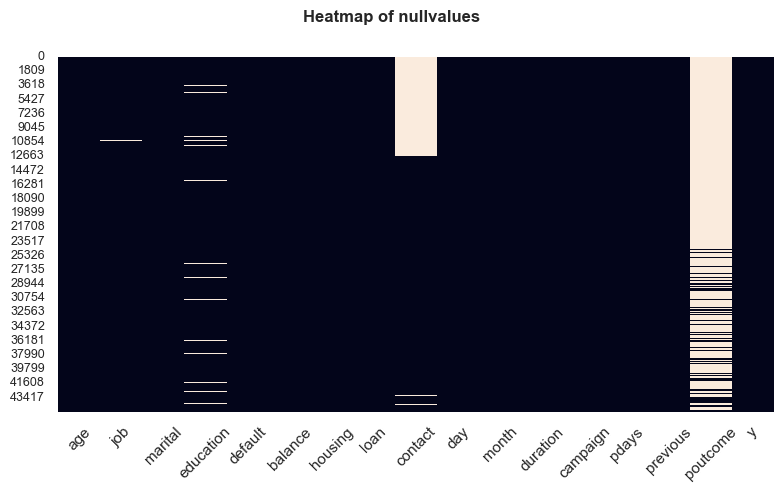

```python
# visualising missing columns
## heatmap of null variables
plt.figure(figsize=(8, 5), layout='tight')
plt.suptitle('Heatmap of nullvalues')

sns.heatmap(df.isnull(),
            cbar=False)
plt.xticks(rotation=45)
plt.yticks(fontsize=9)
plt.show()
```

```python
# sum of null columns
df.isnull().sum()
```

```
age              0
job            288
marital          0
education     1857
default          0
balance          0
housing          0
loan             0
contact      13020
day              0
month            0
duration         0
campaign         0
pdays            0
previous         0
poutcome     36959
y                0
dtype: int64
```

```python
df.head()
```

|  | age | job | marital | education | default | balance | housing | loan | contact | day | month | duration | campaign | pdays | previous | poutcome | y |
| --- | --- | --- | --- | --- | --- | --- | --- | --- | --- | --- | --- | --- | --- | --- | --- | --- | --- |
| 0 | 58 | management | married | tertiary | no | 2143 | yes | no | NaN | 5 | may | 261 | 1 | -1 | 0 | NaN | no |
| 1 | 44 | technician | single | secondary | no | 29 | yes | no | NaN | 5 | may | 151 | 1 | -1 | 0 | NaN | no |
| 2 | 33 | entrepreneur | married | secondary | no | 2 | yes | yes | NaN | 5 | may | 76 | 1 | -1 | 0 | NaN | no |
| 3 | 47 | blue-collar | married | NaN | no | 1506 | yes | no | NaN | 5 | may | 92 | 1 | -1 | 0 | NaN | no |
| 4 | 33 | NaN | single | NaN | no | 1 | no | no | NaN | 5 | may | 198 | 1 | -1 | 0 | NaN | no |

There are four columns with empty rows: job, education, contact and poutcome. These are all categorical columns

The job, education and contact column are columns that we cannot make judgement on what they should be based on the rest of the information from the column. They are unique to individual identity profile and as such they are independent of the rest of the data in the columns.

Then for the poutcome column, it was verified in the cells above that all the categorical values in the column except for nan, were clients who had been contacted previously. It therefore means that nan in poutcome simply means that the client has not been contacted. However in this column we have three other categories: other, failure and success. It may seem that failure and other are the same thing but it isn't. Also, nan and failure or other are not the same. This is because when making a decision to contact a client, these values are in the record of the client and play a role in how the service is presented to the client. *If we wish to model a data where we have no previous knowledge of what the client outcome would be, then all data with previous contact should be dropped. But then there is a problem with this strategy. This is because the campaign column describes the number of contacts made to the client during this campaign. It would mean that any contact greater than 1 will be dropped because if more than a single contact was made, it is likely that the first was a failure (although this can't be verified). Also, the campaign, pdays, previous, month, poutcome, day_of_week willl be redundant as they will add no value to the dataset.* To clean this column, I will rename all nan with zero previous outcome with another categorical word: nil

Then for job, education and contact columns which are independent, i will fill these up with the most frequent values in the columns

```python
## before filling the columns, lets check for rows with Nan values for job, education, contact and poutcome
all_null = (df['job'].isna()) & (df['education'].isna()) & (df['contact'].isna()) & (df['poutcome'].isna())

df[all_null].shape
```

```
(54, 17)
```

```python
## 54 columns in total with all the columns null for job, education, contact and poutcome
four_null_cols = df[all_null]
four_null_cols
```

|  | age | job | marital | education | default | balance | housing | loan | contact | day | month | duration | campaign | pdays | previous | poutcome | y |
| --- | --- | --- | --- | --- | --- | --- | --- | --- | --- | --- | --- | --- | --- | --- | --- | --- | --- |
| 4 | 33 | NaN | single | NaN | no | 1 | no | no | NaN | 5 | may | 198 | 1 | -1 | 0 | NaN | no |
| 216 | 47 | NaN | married | NaN | no | 28 | no | no | NaN | 5 | may | 338 | 2 | -1 | 0 | NaN | no |
| 354 | 59 | NaN | divorced | NaN | no | 27 | no | no | NaN | 5 | may | 347 | 3 | -1 | 0 | NaN | no |
| 876 | 37 | NaN | single | NaN | no | 414 | yes | no | NaN | 7 | may | 131 | 1 | -1 | 0 | NaN | no |
| 2046 | 57 | NaN | married | NaN | no | 106 | no | no | NaN | 12 | may | 836 | 4 | -1 | 0 | NaN | no |
| 2848 | 25 | NaN | single | NaN | no | 329 | yes | no | NaN | 14 | may | 158 | 2 | -1 | 0 | NaN | no |
| 3513 | 55 | NaN | married | NaN | no | 666 | no | no | NaN | 15 | may | 73 | 5 | -1 | 0 | NaN | no |
| 3985 | 46 | NaN | married | NaN | no | 300 | yes | no | NaN | 16 | may | 323 | 3 | -1 | 0 | NaN | no |
| 4750 | 38 | NaN | married | NaN | no | 124 | yes | no | NaN | 20 | may | 37 | 13 | -1 | 0 | NaN | no |
| 6966 | 57 | NaN | married | NaN | no | 327 | yes | no | NaN | 28 | may | 74 | 2 | -1 | 0 | NaN | no |
| 7181 | 29 | NaN | single | NaN | no | 209 | no | no | NaN | 29 | may | 346 | 6 | -1 | 0 | NaN | no |
| 9002 | 59 | NaN | married | NaN | no | 3940 | no | no | NaN | 5 | jun | 48 | 2 | -1 | 0 | NaN | no |
| 9010 | 51 | NaN | divorced | NaN | no | 1649 | no | no | NaN | 5 | jun | 93 | 1 | -1 | 0 | NaN | no |
| 9058 | 51 | NaN | single | NaN | no | 0 | no | no | NaN | 5 | jun | 409 | 1 | -1 | 0 | NaN | no |
| 9093 | 42 | NaN | single | NaN | no | 1316 | no | no | NaN | 5 | jun | 285 | 1 | -1 | 0 | NaN | no |
| 9166 | 36 | NaN | single | NaN | no | 1070 | no | no | NaN | 5 | jun | 346 | 3 | -1 | 0 | NaN | no |
| 9235 | 53 | NaN | married | NaN | no | 1347 | no | no | NaN | 5 | jun | 92 | 2 | -1 | 0 | NaN | no |
| 9370 | 46 | NaN | married | NaN | no | 2505 | no | no | NaN | 6 | jun | 135 | 2 | -1 | 0 | NaN | no |
| 9388 | 56 | NaN | divorced | NaN | no | 2152 | no | no | NaN | 6 | jun | 67 | 1 | -1 | 0 | NaN | no |
| 9400 | 47 | NaN | married | NaN | no | 750 | no | no | NaN | 6 | jun | 188 | 1 | -1 | 0 | NaN | no |
| 9406 | 46 | NaN | married | NaN | no | 613 | no | no | NaN | 6 | jun | 51 | 1 | -1 | 0 | NaN | no |
| 9456 | 35 | NaN | married | NaN | no | 0 | no | no | NaN | 6 | jun | 159 | 3 | -1 | 0 | NaN | no |
| 9597 | 46 | NaN | married | NaN | no | 2367 | no | no | NaN | 6 | jun | 86 | 3 | -1 | 0 | NaN | no |
| 9605 | 47 | NaN | married | NaN | no | 0 | no | no | NaN | 6 | jun | 466 | 2 | -1 | 0 | NaN | no |
| 9894 | 37 | NaN | married | NaN | no | 1699 | no | no | NaN | 9 | jun | 63 | 1 | -1 | 0 | NaN | no |
| 10146 | 51 | NaN | married | NaN | no | 12 | no | no | NaN | 11 | jun | 45 | 1 | -1 | 0 | NaN | no |
| 10168 | 58 | NaN | married | NaN | no | 0 | no | no | NaN | 11 | jun | 464 | 2 | -1 | 0 | NaN | no |
| 10207 | 41 | NaN | single | NaN | no | 1259 | no | no | NaN | 11 | jun | 177 | 8 | -1 | 0 | NaN | no |
| 10220 | 45 | NaN | married | NaN | no | 360 | no | no | NaN | 11 | jun | 157 | 9 | -1 | 0 | NaN | no |
| 10343 | 50 | NaN | single | NaN | no | 490 | no | no | NaN | 12 | jun | 189 | 1 | -1 | 0 | NaN | no |
| 10394 | 52 | NaN | married | NaN | no | 1317 | no | no | NaN | 12 | jun | 58 | 1 | -1 | 0 | NaN | no |
| 10635 | 48 | NaN | married | NaN | no | 3940 | no | no | NaN | 16 | jun | 298 | 6 | -1 | 0 | NaN | no |
| 10867 | 47 | NaN | married | NaN | no | 1728 | no | no | NaN | 17 | jun | 98 | 1 | -1 | 0 | NaN | no |
| 11062 | 45 | NaN | married | NaN | no | 1979 | no | no | NaN | 17 | jun | 76 | 3 | -1 | 0 | NaN | no |
| 11154 | 58 | NaN | married | NaN | no | 219 | no | no | NaN | 18 | jun | 55 | 1 | -1 | 0 | NaN | no |
| 11208 | 51 | NaN | married | NaN | no | 167 | no | no | NaN | 18 | jun | 205 | 4 | -1 | 0 | NaN | no |
| 11258 | 50 | NaN | married | NaN | no | 200 | no | no | NaN | 18 | jun | 18 | 6 | -1 | 0 | NaN | no |
| 11269 | 47 | NaN | married | NaN | no | 1880 | no | no | NaN | 18 | jun | 64 | 2 | -1 | 0 | NaN | no |
| 11322 | 57 | NaN | divorced | NaN | no | 4244 | no | no | NaN | 18 | jun | 626 | 5 | -1 | 0 | NaN | no |
| 11334 | 48 | NaN | married | NaN | no | 2261 | no | no | NaN | 18 | jun | 445 | 3 | -1 | 0 | NaN | no |
| 11523 | 40 | NaN | married | NaN | no | 35 | no | no | NaN | 19 | jun | 40 | 1 | -1 | 0 | NaN | no |
| 11533 | 60 | NaN | married | NaN | no | 652 | no | no | NaN | 19 | jun | 525 | 1 | -1 | 0 | NaN | no |
| 11540 | 46 | NaN | single | NaN | no | 63 | no | no | NaN | 19 | jun | 235 | 1 | -1 | 0 | NaN | no |
| 11666 | 57 | NaN | married | NaN | no | 2266 | no | no | NaN | 20 | jun | 42 | 5 | -1 | 0 | NaN | no |
| 11747 | 43 | NaN | married | NaN | no | 1517 | no | no | NaN | 20 | jun | 45 | 1 | -1 | 0 | NaN | no |
| 11752 | 42 | NaN | single | NaN | yes | 61 | no | no | NaN | 20 | jun | 115 | 1 | -1 | 0 | NaN | no |
| 11812 | 56 | NaN | married | NaN | no | 0 | no | no | NaN | 20 | jun | 471 | 2 | -1 | 0 | NaN | no |
| 12085 | 59 | NaN | married | NaN | no | 2443 | no | no | NaN | 20 | jun | 8 | 8 | -1 | 0 | NaN | no |
| 12147 | 56 | NaN | married | NaN | no | 361 | no | no | NaN | 20 | jun | 247 | 7 | -1 | 0 | NaN | no |
| 12187 | 44 | NaN | single | NaN | no | 1239 | no | no | NaN | 20 | jun | 39 | 4 | -1 | 0 | NaN | no |
| 12203 | 54 | NaN | married | NaN | no | 2508 | no | no | NaN | 20 | jun | 34 | 8 | -1 | 0 | NaN | no |
| 12218 | 56 | NaN | married | NaN | no | 778 | no | no | NaN | 20 | jun | 32 | 4 | -1 | 0 | NaN | no |
| 24081 | 57 | NaN | married | NaN | no | 19268 | no | no | NaN | 23 | oct | 301 | 1 | -1 | 0 | NaN | yes |
| 24175 | 46 | NaN | married | NaN | no | 677 | no | no | NaN | 13 | nov | 722 | 1 | -1 | 0 | NaN | no |

it appears that a good number of these dataset where the four columns are null came from the month of june. dropping all these 54 rows may affect the data for the month of june in particular. Lets review how much data are for the month of June

```python
jun = df['month'] == 'jun'

# total june data
df[jun].shape
```

```
(5341, 17)
```

It appears that the rows with all four columns empty can be dropped safely without affecting the data and then focus on filling in the rest of the rows as suggested above

```python
df.drop(four_null_cols.index, axis=0, inplace=True)
```

```python
## using simple imputer
from sklearn.impute import SimpleImputer

imputer_a = SimpleImputer(strategy='most_frequent')

df[['job', 'education', 'contact']] = imputer_a.fit_transform(df[['job', 'education', 'contact']])
```

Before filling the poutcome column, it would be expected that where the poutcome is NaN, that the previous column should then be zero. This is because previous outcome significies no previous contact. Where these conditions do not hold, then there is an error in the recorded data. This shall be investigated and will be filled with 'other' category

```python
# columns with previous contact but nan outcome
pout = (df['poutcome'].isna()) & (df['previous']!=0)

pout_error = df[pout]
pout_error
```

|  | age | job | marital | education | default | balance | housing | loan | contact | day | month | duration | campaign | pdays | previous | poutcome | y |
| --- | --- | --- | --- | --- | --- | --- | --- | --- | --- | --- | --- | --- | --- | --- | --- | --- | --- |
| 40658 | 61 | retired | married | tertiary | no | 3140 | yes | yes | cellular | 6 | aug | 975 | 4 | 98 | 1 | NaN | yes |
| 41821 | 39 | management | married | tertiary | no | 184 | no | no | cellular | 15 | oct | 206 | 1 | 168 | 5 | NaN | no |
| 42042 | 26 | admin. | single | secondary | no | 338 | no | no | cellular | 29 | oct | 209 | 1 | 188 | 2 | NaN | yes |
| 43978 | 30 | technician | single | secondary | no | 254 | yes | yes | cellular | 24 | jun | 167 | 3 | 416 | 2 | NaN | no |
| 45021 | 37 | management | married | secondary | no | 209 | no | no | cellular | 14 | oct | 183 | 3 | 528 | 7 | NaN | no |

```python
## getting value counts of affected column
df[df['poutcome'].isna()]['previous'].value_counts()
```

```
previous
0    36900
2        2
1        1
5        1
7        1
Name: count, dtype: int64
```

```python
## Filling these columns
imputer_c = SimpleImputer(strategy='constant', fill_value='other')


other_cat_fill = df.loc[pout_error.index, 'poutcome']
df.loc[pout_error.index, 'poutcome'] = imputer_c.fit_transform(pout_error[['poutcome']])
```

```python
## checking the outcome
df[df['poutcome'].isna()]['previous'].value_counts()
```

```
previous
0    36900
Name: count, dtype: int64
```

```python
## Filling there rest of the poutcome column with nil
imputer_b = SimpleImputer(strategy='constant', fill_value = 'nil')

df[['poutcome']] = imputer_b.fit_transform(df[['poutcome']])
```

```python
df['poutcome'].value_counts()
```

```
poutcome
nil        36900
failure     4901
other       1844
success     1511
Name: count, dtype: int64
```

```python
# cheking null values
df.isnull().sum()
```

```
age          0
job          0
marital      0
education    0
default      0
balance      0
housing      0
loan         0
contact      0
day          0
month        0
duration     0
campaign     0
pdays        0
previous     0
poutcome     0
y            0
dtype: int64
```

### Feature Engineering

```python
df.head()
```

|  | age | job | marital | education | default | balance | housing | loan | contact | day | month | duration | campaign | pdays | previous | poutcome | y |
| --- | --- | --- | --- | --- | --- | --- | --- | --- | --- | --- | --- | --- | --- | --- | --- | --- | --- |
| 0 | 58 | management | married | tertiary | no | 2143 | yes | no | cellular | 5 | may | 261 | 1 | -1 | 0 | nil | no |
| 1 | 44 | technician | single | secondary | no | 29 | yes | no | cellular | 5 | may | 151 | 1 | -1 | 0 | nil | no |
| 2 | 33 | entrepreneur | married | secondary | no | 2 | yes | yes | cellular | 5 | may | 76 | 1 | -1 | 0 | nil | no |
| 3 | 47 | blue-collar | married | secondary | no | 1506 | yes | no | cellular | 5 | may | 92 | 1 | -1 | 0 | nil | no |
| 5 | 35 | management | married | tertiary | no | 231 | yes | no | cellular | 5 | may | 139 | 1 | -1 | 0 | nil | no |

```python
## creating a copy of the data
campaign = df.copy()
```

##### gap between pdays and current contact in years

```python
# generating additional features from pdays
campaign['pyears'] = 1
campaign['pyears'] = campaign['pyears'].mask(df['pdays']>364, 2)
#campaign['pyears'] = campaign['pyears'].mask((df['pdays']>364) & (df['pdays']<730), 2)
campaign['pyears'] = campaign['pyears'].mask(df['pdays']>=730 , 3)
campaign['pyears'].value_counts()
```

```
pyears
1    44462
2      664
3       30
Name: count, dtype: int64
```

##### dropping duration and campaign column

Duration is the length of the last contact in seconds. This cannot be known until the outcome is determined. By the end of the call, the result is yes or no.  
Campaign column describes the number of contacts performed during this campaign and for this client (numeric, includes last contact). This modeling wants to predict what the outcome will be for a potential client possibly before launching another marketing campaign. Therefore, data about the number of contacts made in the present marketing campaign would not be available during the campaign planning. Fog avoidance of leakage, i will drop the campaign column also.

```python
campaign = campaign.drop(['duration', 'campaign'], axis = 1)
campaign.columns
```

```
Index(['age', 'job', 'marital', 'education', 'default', 'balance', 'housing',
       'loan', 'contact', 'day', 'month', 'pdays', 'previous', 'poutcome', 'y',
       'pyears'],
      dtype='object')
```

##### handling the month columns

```python
# converting the months to numerical months
campaign['month'] =  pd.to_datetime(campaign['month'], format='%b').dt.month
campaign['month'].unique()
```

```
array([ 5,  6,  7,  8, 10, 11, 12,  1,  2,  3,  4,  9], dtype=int32)
```

```python
campaign['month'].dtypes
```

```
dtype('int32')
```

#### Correlation matrix (feature vs target)

```python
# Converting the target column to ordinal values

campaign['y'] = np.where(campaign['y']== 'yes', 1, 0)

camp_corr = campaign.corr(method='spearman',numeric_only=True)
camp_corr
```

|  | age | balance | day | month | pdays | previous | y | pyears |
| --- | --- | --- | --- | --- | --- | --- | --- | --- |
| age | 1.000000 | 0.096171 | -0.008798 | 0.114352 | -0.017075 | -0.011501 | -0.008583 | -0.004635 |
| balance | 0.096171 | 1.000000 | 0.001317 | 0.052025 | 0.069800 | 0.079677 | 0.100315 | -0.002056 |
| day | -0.008798 | 0.001317 | 1.000000 | 0.116922 | -0.092346 | -0.087880 | -0.029752 | -0.034886 |
| month | 0.114352 | 0.052025 | 0.116922 | 1.000000 | -0.125021 | -0.105712 | 0.012294 | -0.010823 |
| pdays | -0.017075 | 0.069800 | -0.092346 | -0.125021 | 1.000000 | 0.985609 | 0.153940 | 0.316110 |
| previous | -0.011501 | 0.079677 | -0.087880 | -0.105712 | 0.985609 | 1.000000 | 0.169036 | 0.256399 |
| y | -0.008583 | 0.100315 | -0.029752 | 0.012294 | 0.153940 | 0.169036 | 1.000000 | 0.061465 |
| pyears | -0.004635 | -0.002056 | -0.034886 | -0.010823 | 0.316110 | 0.256399 | 0.061465 | 1.000000 |

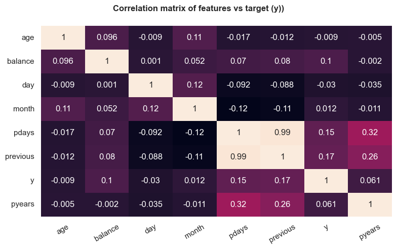

```python
fig = plt.figure(figsize=[8,5], layout='tight')

sns.heatmap(camp_corr.round(3), annot=True, cbar=False)
plt.xticks(rotation=30)
plt.yticks(rotation=0)
plt.suptitle('Correlation matrix of features vs target (y))')
plt.show()
```

Ther are no strong correlations between target and features although by comparison, it can be seen that balance, pdays, previous columns scored up to 0.1 in correlation with y.

##### Feature importances

```python
from sklearn.feature_selection import mutual_info_classif


discrete_features = ['age', 'balance', 'day', 'month', 'pdays', 'previous', 'pyears']
y = campaign['y']
X = campaign.drop('y', axis=1)

mi = mutual_info_classif(X[discrete_features], y, random_state=92)
mi
```

```
array([0.01272842, 0.0235624 , 0.00684303, 0.02669341, 0.0248325 ,
       0.01230752, 0.00716109])
```

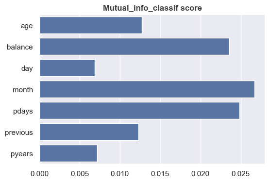

```python
fig, ax = plt.subplots(figsize=(6, 4))
sns.barplot(x=mi, y=discrete_features, ax=ax)
ax.set_title('Mutual_info_classif score')
plt.show()
```

Comparing the correlation result and the mutual_info_classif, pdays and balance are very consistent in the correlation with target. Also the month column shows very high score in mutual info results. Then finally, previous and age column show some level of importance.

### Model Preparations

The numeric columns in the dataset include:

> Age, balance, pdays and previous

Ordinal columns include:

> default, housing, loan, day, month, pyears and education. The ordinal columns have orders of magnitude eg is the day of the month (1<2..<<30) and education level (primary<secondary<tertiary)

Onehot encode categorical columns include:

> job, marital, contact adn poutcome

```python
from sklearn.model_selection import (train_test_split,
                                    GridSearchCV,
                                    RandomizedSearchCV,
                                    cross_validate,
                                    StratifiedKFold)
from sklearn.preprocessing import (PowerTransformer,
                                    RobustScaler,
                                    OneHotEncoder,
                                    OrdinalEncoder)
from sklearn.compose import ColumnTransformer
from sklearn.pipeline import Pipeline, make_pipeline

from sklearn.metrics import (roc_auc_score,
                            ConfusionMatrixDisplay,
                            precision_recall_curve,
                            average_precision_score,
                            RocCurveDisplay,
                            f1_score,
                            recall_score,
                            precision_score
)

from sklearn.feature_selection import SelectKBest
```

```python
high_num = ['age', 'balance', 'pdays', 'previous']
remain = ['day', 'month', 'pyears']
ordinals = ['education','default', 'housing', 'loan']
onehotenc = ['job', 'marital', 'contact', 'poutcome']

ordinal_key = [['primary', 'secondary', 'tertiary'],['yes', 'no'],['yes', 'no'],['yes', 'no']]
```

```python
power_transform = make_pipeline(PowerTransformer(),
                                RobustScaler()
                               )
ordinal_transform = make_pipeline(OrdinalEncoder(categories=ordinal_key))

onehot_transform = make_pipeline(OneHotEncoder())

processor = ColumnTransformer([('scaler', power_transform, high_num),
                               ('encoder_encode', ordinal_transform, ordinals),
                               ('encoder_onehot', onehot_transform, onehotenc),
                               ('remaining', 'passthrough', remain)],
                              verbose_feature_names_out = False,
                              n_jobs=-1
                             )


X_train, X_test, y_train, y_test = train_test_split(X, y, test_size=0.25, stratify=y, random_state=678)

inner_cv = StratifiedKFold(n_splits=5) # a 5 fold cross validation for hyperparameter tuning
```

```python
X_transformed = processor.fit_transform(X_train)
X_transformed = pd.DataFrame(X_transformed, columns=processor.get_feature_names_out())
X_transformed['y'] = y_train
```

```python
X_transform_corr = X_transformed.corr(method='spearman')
```

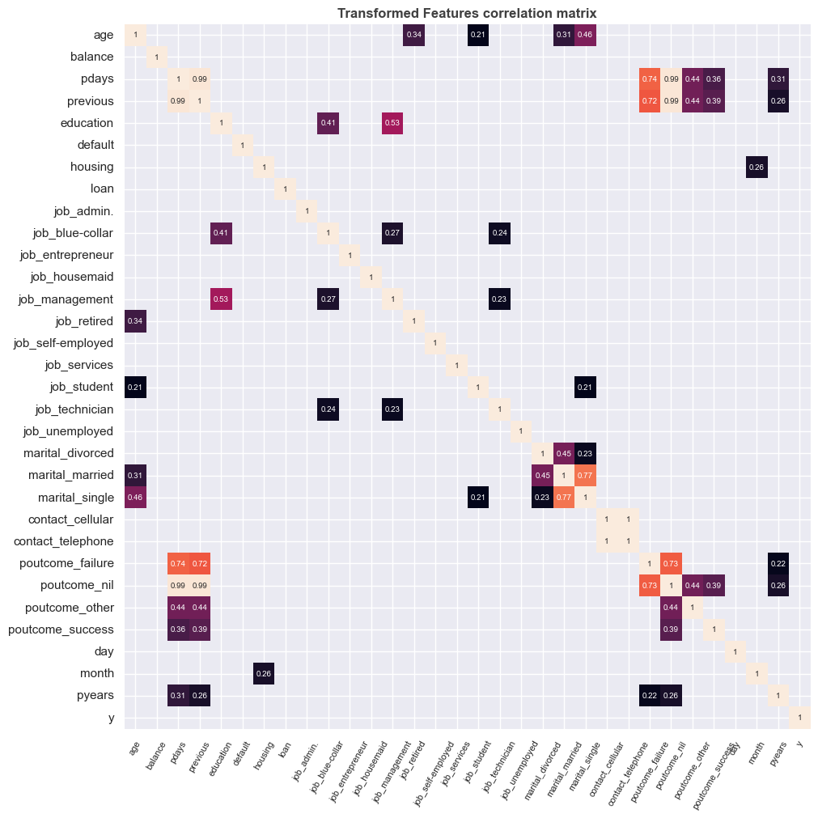

```python
fig, ax = plt.subplots(figsize=(10,10), layout='constrained')

sns.heatmap(abs(X_transform_corr.round(2)), cbar=False,
            annot=True, ax=ax,
            mask=(abs(X_transform_corr.round(2))<0.2),
            annot_kws=({'fontsize':7}))
ax.set_title('Transformed Features correlation matrix')
ax.tick_params(axis='x', which='major', rotation=60, labelsize=8)
plt.show()
```

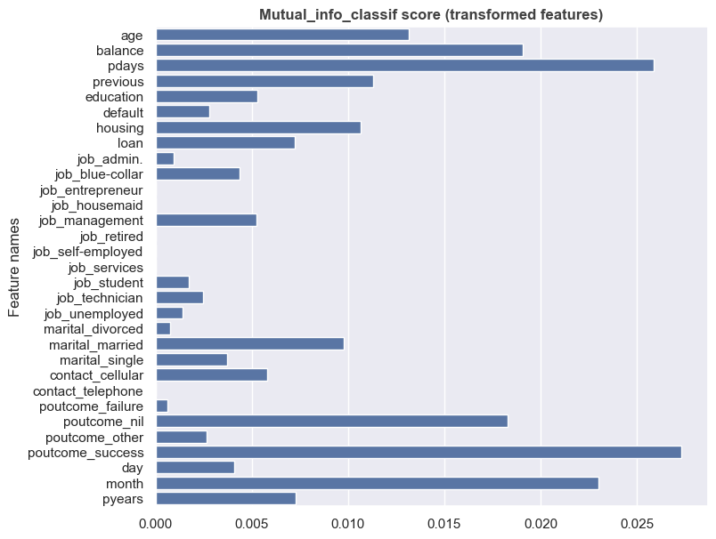

```python
## mutual info scoring
X_transf = X_transformed.drop('y', axis=1)

new_mi = mutual_info_classif(X_transf, y_train, random_state=23)

fig, ax = plt.subplots(figsize=(8, 7))
sns.barplot(x=new_mi, y=X_transf.columns, ax=ax)
ax.set_title('Mutual_info_classif score (transformed features)')
ax.set_ylabel('Feature names')
plt.show()
```

The transformed features do not show strong correlations with the target y using spearman correlation. However, using mutual info scoring, ther are a number of features which show good scores with the target.

#### Modelling

In modelling the data, it is important to bear these business objectives: It is important that we identify all positive response clients and so `Recall for the positive class is very important`. This is because:

1. False negative (missing a willing subscriber) = lost revenue opportunity
2. False positive (calling an unwilling client ) = waste of company resources/time - customer disturbance/annoyance

For the modeling of the data, I will employ three approaches with gridsearch to the model considering the class imbalance of the positive label.

1. Sklearn estimators using class weight. The following classifiers will be used model the data using the class weight of sklearn: logistic regression, sgdclassifier, knnclassifier and votingclassifier
2. Combining sklearn with SMOTE from Imbalance to account for the class imbalance
3. finally lightGBM for the data classification

For the evaluation: I will employ the following

1. ROC_AUC scores
2. Precision-recall curves
3. confusion matrix and confusion matrix display

Finally I will employ cross validation on the best performing model

```python
### Table of class count/subscribers vs non subscribers

class_count = y_true.value_counts()
class_count = pd.DataFrame(class_count)
class_percent = pd.DataFrame((y_true.value_counts(normalize=True)*100).round(2))
subscription_table = pd.concat([class_count, class_percent], axis=1).reindex()
subscription_table
```

| y | count | proportion |
| --- | --- | --- |
| no | 39922 | 88.3 |
| yes | 5289 | 11.7 |

```python
## Logistic regression

from sklearn.linear_model import LogisticRegression

lr_pipe = Pipeline(steps=[('preprocessor', processor),
                          ('select_features', SelectKBest(mutual_info_classif, k=10)),
                          ('logistic_model', LogisticRegression(class_weight='balanced', random_state=14,))]
                  )

lr_grid_params = {'logistic_model__C':[0.1, 0.5, 1, 5, 10],
                  'logistic_model__solver': ['liblinear', 'newton-cholesky'],
                  'logistic_model__max_iter':[100, 1000, 5000]
                 }

lr_grid = GridSearchCV(lr_pipe,
                       param_grid=lr_grid_params,
                       scoring='roc_auc',
                       cv=inner_cv,
                       n_jobs=-1
                      )

lr_grid.fit(X_train, y_train)
```

```
GridSearchCV(cv=StratifiedKFold(n_splits=5, random_state=None, shuffle=False),
             estimator=Pipeline(steps=[('preprocessor',
                                        ColumnTransformer(n_jobs=-1,
                                                          transformers=[('scaler',
                                                                         Pipeline(steps=[('powertransformer',
                                                                                          PowerTransformer()),
                                                                                         ('robustscaler',
                                                                                          RobustScaler())]),
                                                                         ['age',
                                                                          'balance',
                                                                          'pdays',
                                                                          'previous']),
                                                                        ('encoder_encode',
                                                                         Pipeline(steps=[('ordinalencoder',...
                                       ('select_features',
                                        SelectKBest(score_func=<function mutual_info_classif at 0x0000022E16B21240>)),
                                       ('logistic_model',
                                        LogisticRegression(class_weight='balanced',
                                                           random_state=14))]),
             n_jobs=-1,
             param_grid={'logistic_model__C': [0.1, 0.5, 1, 5, 10],
                         'logistic_model__max_iter': [100, 1000, 5000],
                         'logistic_model__solver': ['liblinear',
                                                    'newton-cholesky']},
             scoring='roc_auc')
```

```python
def gridsearch_results(model, scores : list) -> dict:
    results = {key:np.round(model.cv_results_[key].mean(), 3)
               for key in model.cv_results_.keys()
               if key in scores}
    return results
```

```python
gridsearch_results(lr_grid, ['mean_test_score', 'std_test_score', 'rank_test_score'])
```

```
{'mean_test_score': np.float64(0.702),
 'std_test_score': np.float64(0.003),
 'rank_test_score': np.float64(15.5)}
```

```python
best_lr_model = lr_grid.best_estimator_
lr_grid.best_params_
```

```
{'logistic_model__C': 1,
 'logistic_model__max_iter': 1000,
 'logistic_model__solver': 'liblinear'}
```

```python
## SGDClassifier

from sklearn.linear_model import SGDClassifier

sgd_pipe = Pipeline([('preprocessor', processor),
                     ('sgd_model', SGDClassifier(class_weight='balanced', random_state=40))
                    ])
sgd_params = {'sgd_model__loss':['hinge', 'log_loss', 'modified_huber'],
              'sgd_model__alpha':[0.0001, 0.001, 0.1],
              'sgd_model__penalty':['l2', 'l1', 'elasticnet'],
              'sgd_model__learning_rate': ['constant', 'optimal', 'invscaling'],
              'sgd_model__eta0': [0.01, 0.1, 0.5],
              'sgd_model__max_iter':[1000, 5000]
             }

sgd_grid = GridSearchCV(sgd_pipe,
                        param_grid=sgd_params,
                        scoring='roc_auc',
                        cv=inner_cv,
                        n_jobs=-1
                       )

sgd_grid.fit(X_train, y_train)
```

```
GridSearchCV(cv=StratifiedKFold(n_splits=5, random_state=None, shuffle=False),
             estimator=Pipeline(steps=[('preprocessor',
                                        ColumnTransformer(n_jobs=-1,
                                                          transformers=[('scaler',
                                                                         Pipeline(steps=[('powertransformer',
                                                                                          PowerTransformer()),
                                                                                         ('robustscaler',
                                                                                          RobustScaler())]),
                                                                         ['age',
                                                                          'balance',
                                                                          'pdays',
                                                                          'previous']),
                                                                        ('encoder_encode',
                                                                         Pipeline(steps=[('ordinalencoder',...
                                        SGDClassifier(class_weight='balanced',
                                                      random_state=40))]),
             n_jobs=-1,
             param_grid={'sgd_model__alpha': [0.0001, 0.001, 0.1],
                         'sgd_model__eta0': [0.01, 0.1, 0.5],
                         'sgd_model__learning_rate': ['constant', 'optimal',
                                                      'invscaling'],
                         'sgd_model__loss': ['hinge', 'log_loss',
                                             'modified_huber'],
                         'sgd_model__max_iter': [1000, 5000],
                         'sgd_model__penalty': ['l2', 'l1', 'elasticnet']},
             scoring='roc_auc')
```

```python
gridsearch_results(sgd_grid, ['mean_test_score', 'std_test_score', 'rank_test_score'])
```

```
{'mean_test_score': np.float64(0.67),
 'std_test_score': np.float64(0.023),
 'rank_test_score': np.float64(242.352)}
```

```python
best_sgd_model = sgd_grid.best_estimator_
sgd_grid.best_params_
```

```
{'sgd_model__alpha': 0.0001,
 'sgd_model__eta0': 0.5,
 'sgd_model__learning_rate': 'invscaling',
 'sgd_model__loss': 'log_loss',
 'sgd_model__max_iter': 1000,
 'sgd_model__penalty': 'l1'}
```

```python
## KNeighborsClassifier
from sklearn.neighbors import KNeighborsClassifier

kn_pipe = Pipeline([('preprocessor', processor),
                    ('kn_model', KNeighborsClassifier())
                   ])


kn_params = {'kn_model__n_neighbors': [3, 4, 5],
             'kn_model__weights':['uniform','distance'],
             'kn_model__algorithm': ['ball_tree', 'kd_tree', 'brute'],
             'kn_model__leaf_size':[10, 30, 50],
             'kn_model__metric': ['l1', 'l2']
            }

kn_grid = GridSearchCV(kn_pipe,
                       param_grid=kn_params,
                       cv=inner_cv,
                       scoring='roc_auc',
                       n_jobs=-1
                      )
kn_grid.fit(X_train, y_train)
```

```
GridSearchCV(cv=StratifiedKFold(n_splits=5, random_state=None, shuffle=False),
             estimator=Pipeline(steps=[('preprocessor',
                                        ColumnTransformer(n_jobs=-1,
                                                          transformers=[('scaler',
                                                                         Pipeline(steps=[('powertransformer',
                                                                                          PowerTransformer()),
                                                                                         ('robustscaler',
                                                                                          RobustScaler())]),
                                                                         ['age',
                                                                          'balance',
                                                                          'pdays',
                                                                          'previous']),
                                                                        ('encoder_encode',
                                                                         Pipeline(steps=[('ordinalencoder',...
                                                                        ('remaining',
                                                                         'passthrough',
                                                                         ['day',
                                                                          'month',
                                                                          'pyears'])],
                                                          verbose_feature_names_out=False)),
                                       ('kn_model', KNeighborsClassifier())]),
             n_jobs=-1,
             param_grid={'kn_model__algorithm': ['ball_tree', 'kd_tree',
                                                 'brute'],
                         'kn_model__leaf_size': [10, 30, 50],
                         'kn_model__metric': ['l1', 'l2'],
                         'kn_model__n_neighbors': [3, 4, 5],
                         'kn_model__weights': ['uniform', 'distance']},
             scoring='roc_auc')
```

```python
gridsearch_results(kn_grid, ['mean_test_score', 'std_test_score', 'rank_test_score'])
```

```
{'mean_test_score': np.float64(0.681),
 'std_test_score': np.float64(0.009),
 'rank_test_score': np.float64(52.759)}
```

```python
best_kn_model = kn_grid.best_estimator_
kn_grid.best_params_
```

```
{'kn_model__algorithm': 'ball_tree',
 'kn_model__leaf_size': 10,
 'kn_model__metric': 'l2',
 'kn_model__n_neighbors': 5,
 'kn_model__weights': 'distance'}
```

```python
### votingclassifier

from sklearn.ensemble import VotingClassifier

estimators = [('log_reg', best_lr_model), ('sgdclass', best_sgd_model), ('knclass', best_kn_model)]


vote = VotingClassifier(estimators=estimators, voting='soft', n_jobs=-1)

vote.fit(X_train, y_train)
```

```
VotingClassifier(estimators=[('log_reg',
                              Pipeline(steps=[('preprocessor',
                                               ColumnTransformer(n_jobs=-1,
                                                                 transformers=[('scaler',
                                                                                Pipeline(steps=[('powertransformer',
                                                                                                 PowerTransformer()),
                                                                                                ('robustscaler',
                                                                                                 RobustScaler())]),
                                                                                ['age',
                                                                                 'balance',
                                                                                 'pdays',
                                                                                 'previous']),
                                                                               ('encoder_encode',
                                                                                Pipeline(steps=[('ordinalencoder',
                                                                                                 OrdinalEncoder(categories=[['primary',
                                                                                                                             'seconda...
                                                                                 'default',
                                                                                 'housing',
                                                                                 'loan']),
                                                                               ('encoder_onehot',
                                                                                Pipeline(steps=[('onehotencoder',
                                                                                                 OneHotEncoder())]),
                                                                                ['job',
                                                                                 'marital',
                                                                                 'contact',
                                                                                 'poutcome']),
                                                                               ('remaining',
                                                                                'passthrough',
                                                                                ['day',
                                                                                 'month',
                                                                                 'pyears'])],
                                                                 verbose_feature_names_out=False)),
                                              ('kn_model',
                                               KNeighborsClassifier(algorithm='ball_tree',
                                                                    leaf_size=10,
                                                                    metric='l2',
                                                                    weights='distance'))]))],
                 n_jobs=-1, voting='soft')
```

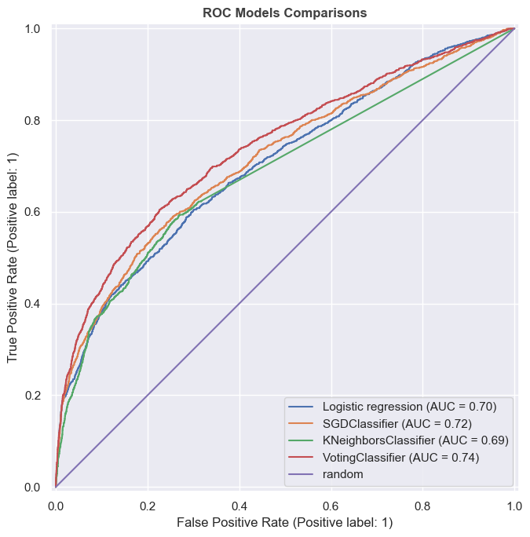

```python
## plotting the roccurves

models = {'Logistic regression': best_lr_model,
          'SGDClassifier': best_sgd_model,
          'KNeighborsClassifier': best_kn_model,
          'VotingClassifier':vote
         }

fig, ax = plt.subplots(figsize = (10, 7), layout='tight')

for num, model in models.items():
    y_scores = model.predict_proba(X_test)[:, 1]

    AUC_score = roc_auc_score(y_test, y_scores)

    RocCurveDisplay.from_estimator(
    model,
    X_test,
    y_test,
    ax=ax,
    name=f'{num}'
    )

ax.plot([0,1],[0,1], label='random')
ax.set_title('ROC Models Comparisons')
ax.grid(True)
plt.legend(loc='lower right')
plt.show()
```

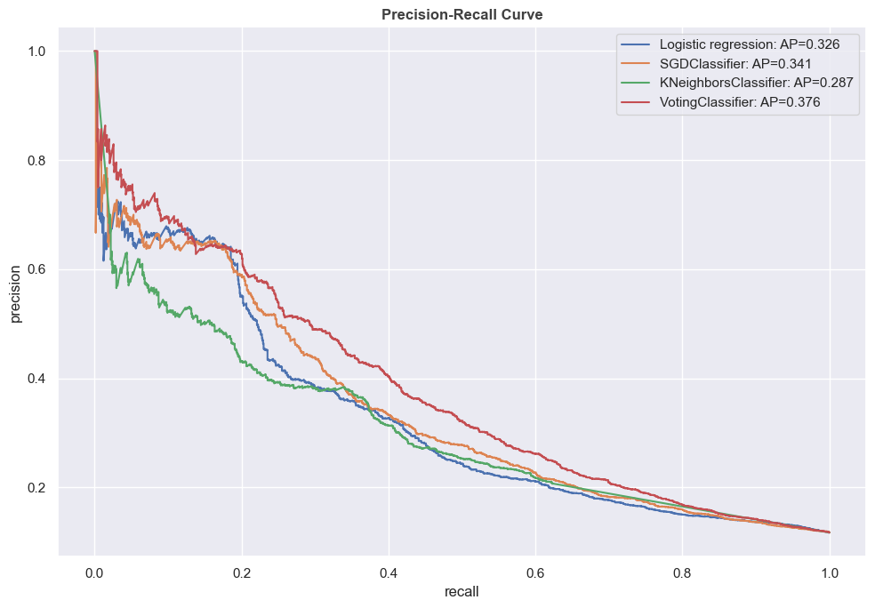

```python
### precision recall_ curves
fig, ax = plt.subplots(figsize=(10, 7), layout='tight')

for num, model in models.items():
    y_scores = model.predict_proba(X_test)[:, 1]

    precision, recall, thresholds = precision_recall_curve(y_test, y_scores)
    average_precision = average_precision_score(y_test, y_scores)

    ax.plot(recall, precision, label=f'{num}: AP={average_precision:.3f}')

ax.set_xlabel('recall')
ax.set_ylabel('precision')
ax.set_title('Precision-Recall Curve')
ax.grid(True)
plt.legend()
plt.show()
```

Based on the models results, the average_precision centers around 0.3 and therefore, I will use this value for my threshold in predictions. At this value, and knowing that the positive class is only 11.7% which means a random classification would give a precision of 0.117, it would mean that a threshold of 0.3 is 3x better than random classification.

This threshold will be used for all estimators

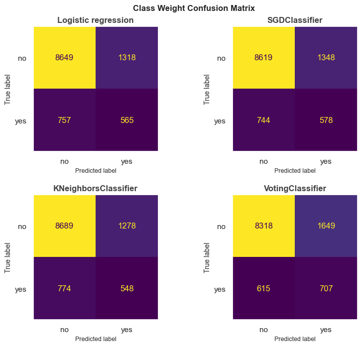

```python
models = {'Logistic regression': best_lr_model,
          'SGDClassifier': best_sgd_model,
          'KNeighborsClassifier': best_kn_model,
          'VotingClassifier':vote
         }


def plot_confusion_matrix(models: dict, X, y, target_precision=0.3, figsize=(8,7), title='', plot=True) -> dict :

    models_metric = {}

    #figure set up
    if plot:
        fig = plt.figure(figsize=figsize, layout='constrained')
        plt.suptitle(f'{title} Confusion Matrix')
        pos = 0

    #Compute threshold and predict X_test
    for name, model in models.items():
        y_scores = model.predict_proba(X)[:, 1]
        precision, recall, thresholds = precision_recall_curve(y, y_scores)
        idx = np.where(precision >= target_precision)[0][0]
        threshold_30p = thresholds[idx]
        y_pred_threshold = (y_scores >= threshold_30p).astype(int)

        ## Metric scores
        summary = {}
        summary['AUC'] = (roc_auc_score(y, y_scores)).round(3)
        summary['Average_precision'] = (average_precision_score(y, y_scores)).round(3)
        summary['recall'] = np.round(recall_score(y, y_pred_threshold), 3)
        summary['fi_score'] = np.round(f1_score(y, y_pred_threshold), 3)
        summary['precision_score'] = np.round(precision_score(y, y_pred_threshold), 3)
        ## update dictionary
        models_metric[name] = summary

        ## plotting
        if plot:
            ax = plt.subplot(2, 2, pos+1)
            ax = ConfusionMatrixDisplay.from_predictions(y, y_pred_threshold,
                                                 display_labels=['no', 'yes'],
                                                 colorbar=False, ax=ax)
            ax.ax_.set_title(f'{name}')
            ax.ax_.grid(False)
            # ax.ax_.xaxis.label.set_size(10)
            # ax.ax_.yaxis.get_label().set_fontsize(10)
            ax.ax_.set_ylabel('True label', fontsize=10)
            ax.ax_.set_xlabel('Predicted label\n', fontsize=9)
            pos+=1

    plt.show()

    return models_metric


Class_weight_model = plot_confusion_matrix(models, X_test, y_test, title='Class Weight')
```

```python
## Metrics for Class weight model
display('Metrics for Models with class_weight only')
pd.DataFrame(Class_weight_model)
```

```
'Metrics for Models with class_weight only'
```

|  | Logistic regression | SGDClassifier | KNeighborsClassifier | VotingClassifier |
| --- | --- | --- | --- | --- |
| AUC | 0.704 | 0.715 | 0.690 | 0.741 |
| Average_precision | 0.326 | 0.341 | 0.287 | 0.376 |
| recall | 0.427 | 0.437 | 0.415 | 0.535 |
| fi_score | 0.353 | 0.356 | 0.348 | 0.384 |
| precision_score | 0.300 | 0.300 | 0.300 | 0.300 |

**ROC-AUC Scores**: The plot of ROC-AUC curves for the four models used shows that the best performing model is the VotingClassifier with 0.74 AUC score while the poorest is KNeighborsClassifier with AUC score 0.69. However, because the positive label in the class is low, the models performance are also compared by PR-AUC curve.

**Precision-Recall Curve**: The precision recall curve for the four models reveal low precision at high recall. Due to the objective of the model, a high recall will be more beneficial to the model because it will be good to find all clients who are interested in subscribing to the term deposit. At low recall, all the models have high precision and as recall increases, the model that is able to maintain higher precision is the voting classifier. Kneeighborsclassifier easily loses precision early and becomes week in distinguishing positives from negatives. Howver, as recall gets to 0.5, all the model collapse to very low precision and labels many samples positive. On the other hand though, given that only 11.7% of the entire dataset is positive, a random guess will give a precision and recall of only 0.117. Comparing this number to the classifier, it shows the model is learning the pattern with voting classifier 3x better than random guess.

**Confusion Matrix**: The confusion matrix displays the table of results of the predicted X_test using the threshold of 0.3. Overall, the models struggle to predict the positive class as already indicated by the precision_recall curve. For a subscription marketing to client, we can be more confident in the results of the predicted positive classes which are three times better than a random guess.

Finally, the summary metrics for all models reveal that the VotingClassifier outperformed all other models in all metrics

### Class Balance with SMOTE

In this next sequence of model I will explore the SMOTE function of the imbalance library for the four models listed above and compare the results

```python
from imblearn.pipeline import Pipeline  # using the pipeline from imbalance to avoid leakage
from imblearn.over_sampling import SMOTE
```

```python
X_train, X_test, y_train, y_test = train_test_split(X, y, test_size=0.25, stratify=y, random_state=678)

inner_cv = StratifiedKFold(n_splits=5)
```

```python
## logistic regression, gridsearch with Smote inside imbalance pipeline

smote_lr_pipe = Pipeline(steps=[('preprocessor', processor),
                          ('smote', SMOTE(random_state=55)),
                          ('select_features', SelectKBest(mutual_info_classif, k=10)),
                          ('logistic_model', LogisticRegression(random_state=14,))]
                  )

lr_grid_params = {'logistic_model__C':[0.1, 0.5, 1, 5, 10],
                  'logistic_model__solver': ['liblinear', 'newton-cholesky'],
                  'logistic_model__max_iter':[100, 1000, 5000]
                 }

smote_lr = GridSearchCV(smote_lr_pipe,
                       param_grid=lr_grid_params,
                       scoring='roc_auc',
                       cv=inner_cv,
                       n_jobs=-1
                      )

smote_lr.fit(X_train, y_train)
```

```
GridSearchCV(cv=StratifiedKFold(n_splits=5, random_state=None, shuffle=False),
             estimator=Pipeline(steps=[('preprocessor',
                                        ColumnTransformer(n_jobs=-1,
                                                          transformers=[('scaler',
                                                                         Pipeline(steps=[('powertransformer',
                                                                                          PowerTransformer()),
                                                                                         ('robustscaler',
                                                                                          RobustScaler())]),
                                                                         ['age',
                                                                          'balance',
                                                                          'pdays',
                                                                          'previous']),
                                                                        ('encoder_encode',
                                                                         Pipeline(steps=[('ordinalencoder',...
                                       ('smote', SMOTE(random_state=55)),
                                       ('select_features',
                                        SelectKBest(score_func=<function mutual_info_classif at 0x0000022E16B21240>)),
                                       ('logistic_model',
                                        LogisticRegression(random_state=14))]),
             n_jobs=-1,
             param_grid={'logistic_model__C': [0.1, 0.5, 1, 5, 10],
                         'logistic_model__max_iter': [100, 1000, 5000],
                         'logistic_model__solver': ['liblinear',
                                                    'newton-cholesky']},
             scoring='roc_auc')
```

```python
gridsearch_results(smote_lr, ['mean_test_score', 'std_test_score', 'rank_test_score'])
```

```
{'mean_test_score': np.float64(0.703),
 'std_test_score': np.float64(0.005),
 'rank_test_score': np.float64(15.5)}
```

```python
best_smote_lr = smote_lr.best_estimator_
smote_lr.best_params_
```

```
{'logistic_model__C': 10,
 'logistic_model__max_iter': 1000,
 'logistic_model__solver': 'liblinear'}
```

```python
## SGDClassifier with Smote

smote_sgd_pipe = Pipeline([('preprocessor', processor),
                           ('smote', SMOTE(random_state=44)),
                     ('sgd_model', SGDClassifier(random_state=40))
                    ])

sgd_params = {'sgd_model__loss':['hinge', 'log_loss', 'modified_huber'],
              'sgd_model__alpha':[0.0001, 0.001, 0.1],
              'sgd_model__penalty':['l2', 'l1', 'elasticnet'],
              'sgd_model__learning_rate': ['constant', 'optimal', 'invscaling'],
              'sgd_model__eta0': [0.01, 0.1, 0.5],
              'sgd_model__max_iter':[1000, 5000]
             }

smote_sgd = GridSearchCV(smote_sgd_pipe,
                        param_grid=sgd_params,
                        scoring='roc_auc',
                        cv=inner_cv,
                        n_jobs=-1
                       )

smote_sgd.fit(X_train, y_train)
```

```
GridSearchCV(cv=StratifiedKFold(n_splits=5, random_state=None, shuffle=False),
             estimator=Pipeline(steps=[('preprocessor',
                                        ColumnTransformer(n_jobs=-1,
                                                          transformers=[('scaler',
                                                                         Pipeline(steps=[('powertransformer',
                                                                                          PowerTransformer()),
                                                                                         ('robustscaler',
                                                                                          RobustScaler())]),
                                                                         ['age',
                                                                          'balance',
                                                                          'pdays',
                                                                          'previous']),
                                                                        ('encoder_encode',
                                                                         Pipeline(steps=[('ordinalencoder',...
                                       ('sgd_model',
                                        SGDClassifier(random_state=40))]),
             n_jobs=-1,
             param_grid={'sgd_model__alpha': [0.0001, 0.001, 0.1],
                         'sgd_model__eta0': [0.01, 0.1, 0.5],
                         'sgd_model__learning_rate': ['constant', 'optimal',
                                                      'invscaling'],
                         'sgd_model__loss': ['hinge', 'log_loss',
                                             'modified_huber'],
                         'sgd_model__max_iter': [1000, 5000],
                         'sgd_model__penalty': ['l2', 'l1', 'elasticnet']},
             scoring='roc_auc')
```

```python
gridsearch_results(smote_sgd, ['mean_test_score', 'std_test_score', 'rank_test_score'])
```

```
{'mean_test_score': np.float64(0.682),
 'std_test_score': np.float64(0.015),
 'rank_test_score': np.float64(242.325)}
```

```python
best_smote_sgd = smote_sgd.best_estimator_
smote_sgd.best_params_
```

```
{'sgd_model__alpha': 0.001,
 'sgd_model__eta0': 0.1,
 'sgd_model__learning_rate': 'invscaling',
 'sgd_model__loss': 'log_loss',
 'sgd_model__max_iter': 1000,
 'sgd_model__penalty': 'elasticnet'}
```

```python
# Kneighbors classifier with SMOTE
smote_kn_pipe = Pipeline([('preprocessor', processor),
                          ('smote', SMOTE(random_state=55)),
                    ('kn_model', KNeighborsClassifier())
                   ])


kn_params = {'kn_model__n_neighbors': [3, 4, 5],
             'kn_model__weights':['uniform','distance'],
             'kn_model__algorithm': ['ball_tree', 'kd_tree', 'brute'],
             'kn_model__leaf_size':[10, 30, 50],
             'kn_model__metric': ['l1', 'l2']
            }

smote_kn = GridSearchCV(smote_kn_pipe,
                       param_grid=kn_params,
                       cv=inner_cv,
                       scoring='roc_auc',
                       n_jobs=-1
                      )
smote_kn.fit(X_train, y_train)
```

```
GridSearchCV(cv=StratifiedKFold(n_splits=5, random_state=None, shuffle=False),
             estimator=Pipeline(steps=[('preprocessor',
                                        ColumnTransformer(n_jobs=-1,
                                                          transformers=[('scaler',
                                                                         Pipeline(steps=[('powertransformer',
                                                                                          PowerTransformer()),
                                                                                         ('robustscaler',
                                                                                          RobustScaler())]),
                                                                         ['age',
                                                                          'balance',
                                                                          'pdays',
                                                                          'previous']),
                                                                        ('encoder_encode',
                                                                         Pipeline(steps=[('ordinalencoder',...
                                                                          'pyears'])],
                                                          verbose_feature_names_out=False)),
                                       ('smote', SMOTE(random_state=55)),
                                       ('kn_model', KNeighborsClassifier())]),
             n_jobs=-1,
             param_grid={'kn_model__algorithm': ['ball_tree', 'kd_tree',
                                                 'brute'],
                         'kn_model__leaf_size': [10, 30, 50],
                         'kn_model__metric': ['l1', 'l2'],
                         'kn_model__n_neighbors': [3, 4, 5],
                         'kn_model__weights': ['uniform', 'distance']},
             scoring='roc_auc')
```

```python
gridsearch_results(smote_kn, ['mean_test_score', 'std_test_score', 'rank_test_score'])
```

```
{'mean_test_score': np.float64(0.685),
 'std_test_score': np.float64(0.01),
 'rank_test_score': np.float64(52.259)}
```

```python
best_smote_kn = smote_kn.best_estimator_
smote_kn.best_params_
```

```
{'kn_model__algorithm': 'ball_tree',
 'kn_model__leaf_size': 10,
 'kn_model__metric': 'l2',
 'kn_model__n_neighbors': 5,
 'kn_model__weights': 'distance'}
```

```python
## voting classifier with SMOTE


smote_estimators = [('log_reg', best_smote_lr), ('sgdclass', best_smote_sgd), ('knclass', best_smote_kn)]


vote_smote = VotingClassifier(estimators=smote_estimators, voting='soft', n_jobs=-1)

vote_smote.fit(X_train, y_train)
```

```
VotingClassifier(estimators=[('log_reg',
                              Pipeline(steps=[('preprocessor',
                                               ColumnTransformer(n_jobs=-1,
                                                                 transformers=[('scaler',
                                                                                Pipeline(steps=[('powertransformer',
                                                                                                 PowerTransformer()),
                                                                                                ('robustscaler',
                                                                                                 RobustScaler())]),
                                                                                ['age',
                                                                                 'balance',
                                                                                 'pdays',
                                                                                 'previous']),
                                                                               ('encoder_encode',
                                                                                Pipeline(steps=[('ordinalencoder',
                                                                                                 OrdinalEncoder(categories=[['primary',
                                                                                                                             'seconda...
                                                                               ('encoder_onehot',
                                                                                Pipeline(steps=[('onehotencoder',
                                                                                                 OneHotEncoder())]),
                                                                                ['job',
                                                                                 'marital',
                                                                                 'contact',
                                                                                 'poutcome']),
                                                                               ('remaining',
                                                                                'passthrough',
                                                                                ['day',
                                                                                 'month',
                                                                                 'pyears'])],
                                                                 verbose_feature_names_out=False)),
                                              ('smote', SMOTE(random_state=55)),
                                              ('kn_model',
                                               KNeighborsClassifier(algorithm='ball_tree',
                                                                    leaf_size=10,
                                                                    metric='l2',
                                                                    weights='distance'))]))],
                 n_jobs=-1, voting='soft')
```

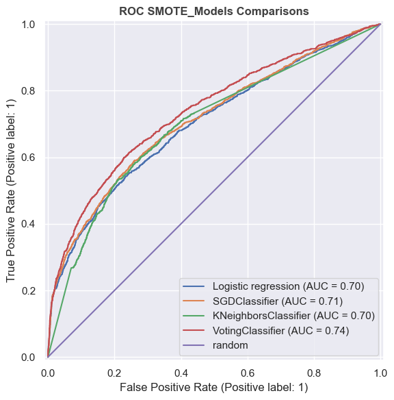

```python
# Ploting ROC Curves for SMOTE models

smote_models = {'Logistic regression': best_smote_lr,
          'SGDClassifier': best_smote_sgd,
          'KNeighborsClassifier': best_smote_kn,
          'VotingClassifier':vote_smote
         }

fig, ax = plt.subplots(figsize = (8, 6), layout='tight')

for num, model in smote_models.items():
    y_scores = model.predict_proba(X_test)[:, 1]

    AUC_score = roc_auc_score(y_test, y_scores)

    RocCurveDisplay.from_estimator(
    model,
    X_test,
    y_test,
    ax=ax,
    name=f'{num}'
    )

ax.plot([0,1],[0,1], label='random')
ax.set_title('ROC SMOTE_Models Comparisons')
ax.grid(True)
plt.legend(loc='lower right')
plt.show()
```

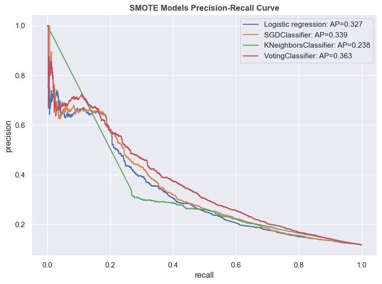

```python
### precision recall_ curves for Smote models

fig, ax = plt.subplots(figsize=(8, 6), layout='tight')

for num, model in smote_models.items():
    y_scores = model.predict_proba(X_test)[:, 1]

    precision, recall, thresholds = precision_recall_curve(y_test, y_scores)
    average_precision = average_precision_score(y_test, y_scores)

    ax.plot(recall, precision, label=f'{num}: AP={average_precision:.3f}')

ax.set_xlabel('recall')
ax.set_ylabel('precision')
ax.set_title('SMOTE Models Precision-Recall Curve')
ax.grid(True)
plt.legend()
plt.show()
```

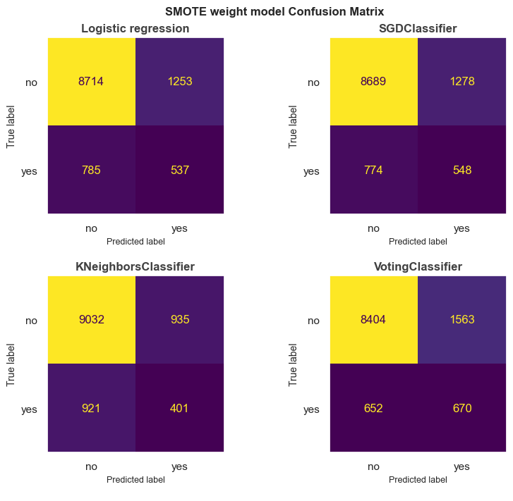

```python
## Confusion matrix and metrics for SMOTE models
smote_models = {'Logistic regression': best_smote_lr,
          'SGDClassifier': best_smote_sgd,
          'KNeighborsClassifier': best_smote_kn,
          'VotingClassifier':vote_smote
         }

SMOTE_weight_models = plot_confusion_matrix(smote_models, X_test, y_test, title='SMOTE weight model')
```

```python
display('SMOTE weight_class Metrics')
pd.DataFrame(SMOTE_weight_models)
```

```
'SMOTE weight_class Metrics'
```

|  | Logistic regression | SGDClassifier | KNeighborsClassifier | VotingClassifier |
| --- | --- | --- | --- | --- |
| AUC | 0.702 | 0.711 | 0.698 | 0.738 |
| Average_precision | 0.327 | 0.339 | 0.238 | 0.363 |
| recall | 0.406 | 0.415 | 0.303 | 0.507 |
| fi_score | 0.345 | 0.348 | 0.302 | 0.377 |
| precision_score | 0.300 | 0.300 | 0.300 | 0.300 |

##### Summary of SMOTE models

The SMOTE models did not show any improvement in the general performance of the data compared to the models without SMOTE class balance. Voting classifier still outperforms the rest of the models in all the metrics.

```python
## Comparing / Summarizing the metrics for both class_weight models and SMOTE models
new_columns = pd.MultiIndex.from_tuples([
    ('Class_weight', 'LogisticRegression'),
    ('Class_weight', 'SGDClassifier'),
    ('Class_weight', 'KNeighborsClassifier'),
    ('Class_weight', 'VotingClassifier'),
    ('SMOTE_model', 'LogisticRegression'),
    ('SMOTE_model', 'SGDClassifier'),
    ('SMOTE_model', 'KNeighborsClassifier'),
    ('SMOTE_model', 'VotingClassifier')
])
Results_Summary = pd.concat([pd.DataFrame(Class_weight_model), pd.DataFrame(SMOTE_weight_models)], axis=1)
Results_Summary.columns = new_columns
Results_Summary = Results_Summary.stack()

Results_Summary
```

|  |  | Class_weight | SMOTE_model |
| --- | --- | --- | --- |
| AUC | KNeighborsClassifier | 0.690 | 0.698 |
|  | LogisticRegression | 0.704 | 0.702 |
|  | SGDClassifier | 0.715 | 0.711 |
|  | VotingClassifier | 0.741 | 0.738 |
| Average_precision | KNeighborsClassifier | 0.287 | 0.238 |
|  | LogisticRegression | 0.326 | 0.327 |
|  | SGDClassifier | 0.341 | 0.339 |
|  | VotingClassifier | 0.376 | 0.363 |
| recall | KNeighborsClassifier | 0.415 | 0.303 |
|  | LogisticRegression | 0.427 | 0.406 |
|  | SGDClassifier | 0.437 | 0.415 |
|  | VotingClassifier | 0.535 | 0.507 |
| fi_score | KNeighborsClassifier | 0.348 | 0.302 |
|  | LogisticRegression | 0.353 | 0.345 |
|  | SGDClassifier | 0.356 | 0.348 |
|  | VotingClassifier | 0.384 | 0.377 |
| precision_score | KNeighborsClassifier | 0.300 | 0.300 |
|  | LogisticRegression | 0.300 | 0.300 |
|  | SGDClassifier | 0.300 | 0.300 |
|  | VotingClassifier | 0.300 | 0.300 |

#### Cross Validation of the best model

Based on the metrics summary table above, the classweight model outperformed the SMOTE class model and therefore the voting classifier shall be cross validated from the class_weight models

```python
## cross validating the voting classifier model

from sklearn.model_selection import cross_validate

outer_cv = StratifiedKFold(n_splits=10) ## using an outer 10-fold CV to avoid ROC-AUC biase estimation

cv_smote_vote = cross_validate(vote, X=X_train, y=y_train, cv=outer_cv, n_jobs=-1, scoring='roc_auc')
```

```python
print(f'Cross validation test scores: {(cv_smote_vote["test_score"]).round(3)}')
```

```
Cross validation test scores: [0.739 0.759 0.754 0.738 0.751 0.72  0.737 0.754 0.75  0.721]
```

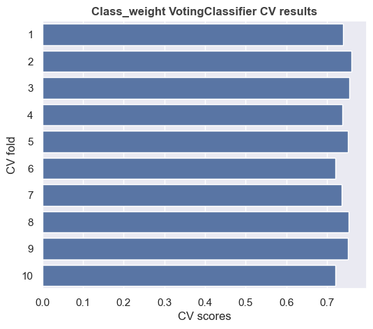

```python
## Plotting the cross validation results
folds = ['1', '2', '3', '4', '5', '6', '7', '8', '9', '10']
fig, ax = plt.subplots(figsize=(6, 5))
sns.barplot(x=cv_smote_vote['test_score'], y=folds, ax=ax)
ax.set_title('Class_weight VotingClassifier CV results')
ax.set_ylabel('CV fold')
ax.set_xlabel('CV scores')
plt.show()
```

```python
## Prediction accurracy of SMOTE votingclassifier
from sklearn.metrics import accuracy_score
predicted_class = vote.predict(X_test)

print("VotingClassifier accuracy score: {} ".format(round(accuracy_score(y_test, predicted_class), 3)))
```

```
VotingClassifier accuracy score: 0.878
```

### LightGBM model

While LightGBM can handle most data ranges and categorical data with inbuilt features, the 'balance' column has a very wide and extreme ranges of -8019 to 102127 which can affect split point efficiency. Therefore, it will be worth scaling this feature. The rest of the features will be handled by LGBM inbuilt functionalities

```python
# importing libraries
from lightgbm import LGBMClassifier
import lightgbm as lgbm
import time
from sklearn.model_selection import RandomizedSearchCV
```

```python
## getting the weight of positive labbel
neg_value = (y==0).sum()
pos_value = (y==1).sum()

scale_pos_weight = round((neg_value/pos_value), 3)
scale_pos_weight
```

```
np.float64(7.539)
```

```python
### setting parameters
categories = ['default', 'housing', 'loan', 'job', 'marital', 'contact', 'poutcome']

X_processed = X.copy()

X_processed['education'].mask(X_processed['education']=='primary', 1, inplace=True)
X_processed['education'].mask(X_processed['education']=='secondary', 2, inplace=True)
X_processed['education'].mask(X_processed['education']=='tertiary', 3, inplace=True)

X_processed['education'] = X_processed['education'].astype(int)

#converting to pandas categories datatype
for col in categories:
    X_processed[col] = X_processed[col].astype('category')


defaults = {'objective':'binary',
            'scale_pos_weight':scale_pos_weight,
            'random_state': 404,
            'n_jobs':-1,
            'first_metric_only': True,
            'metric': 'binary_logloss',
            'force_col_wise': True,
           }


grid_params = {
    'num_leaves': [31, 63, 127],
    'max_depth': [2, 4, 8, -1],
    'min_child_samples': [5, 10, 20],
    'min_split_gain': [0.0, 0.05, 0.1],
    'lambda_l1': [0.0, 0.1, 0.5, 1],
    'lambda_l2': [0.0, 0.1, 0.5, 1],
    'bagging_fraction': [0.7,0.85,  1.0],
    'bagging_freq': [1, 5],
    'feature_fraction': [0.7, 0.9,  1.0],
    'learning_rate': [0.005, 0.01, 0.5, 0.1],
    'n_estimators': [300, 700, 2000, 5000],
    'max_bin': [63, 127, 255],
}


inner_cv = StratifiedKFold(n_splits=5)

scaler = RobustScaler()


X_param, X_test, y_param, y_test = train_test_split(X_processed, y, stratify=y, test_size=0.25, random_state=678)

# scaling the balance column
X_param['balance'] = scaler.fit_transform(X_param[['balance']])
X_test['balance'] = scaler.transform(X_test[['balance']])

#train and validation data split
X_train, X_val, y_train, y_val = train_test_split(X_param, y_param, stratify=y_param, test_size=0.15, random_state=677)
```

```python
#fitting the model
start_t = time.time()

lgb_model = LGBMClassifier(**defaults)

grid_lgbm = RandomizedSearchCV(lgb_model,
                         param_distributions=grid_params,
                         n_iter=75,
                         scoring='roc_auc',
                         cv=inner_cv,
                         n_jobs=-1,
                        random_state=88
                        )

grid_lgbm.fit(X_train, y_train,
              eval_set= [(X_val, y_val)],
              eval_metric='binary_logloss',
              callbacks=[lgbm.early_stopping(stopping_rounds=225)]
             )

stop_t = time.time()
run_t = np.round((stop_t - start_t), 3)
```

[output not shown]

```python
#total run time for grid search
mins= run_t // 60
secs = int(run_t) % 60

display("Total runtime {} minutes {} seconds".format(mins, secs))
```

```
'Total runtime 2.0 minutes 21 seconds'
```

```python
display(grid_lgbm.best_estimator_)
```

```
LGBMClassifier(bagging_fraction=0.85, bagging_freq=5, feature_fraction=0.7,
               first_metric_only=True, force_col_wise=True, lambda_l1=0.1,
               lambda_l2=0.5, learning_rate=0.005, max_bin=255,
               metric='binary_logloss', n_estimators=300, n_jobs=-1,
               num_leaves=127, objective='binary', random_state=404,
               scale_pos_weight=np.float64(7.539))
```

```python
## Cross validation of the lgbm best estimator parameters

lgb_cv = cross_validate(grid_lgbm.best_estimator_, X_param, y_param, cv=StratifiedKFold(n_splits=10), scoring='roc_auc', n_jobs=-1)

print(f'LGB Cross validation test scores: {(lgb_cv["test_score"]).round(3)}\n')
```

```
LGB Cross validation test scores: [0.785 0.794 0.792 0.775 0.79  0.754 0.786 0.793 0.772 0.779]
```

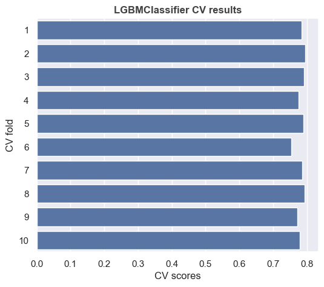

```python
## Plotting corss validation results for LGBMCLassifier

folds = ['1', '2', '3', '4', '5', '6', '7', '8', '9', '10']
fig, ax = plt.subplots(figsize=(6, 5))
sns.barplot(x=lgb_cv['test_score'], y=folds, ax=ax)
ax.set_title('LGBMClassifier CV results')
ax.set_ylabel('CV fold')
ax.set_xlabel('CV scores')
plt.show()
```

[output not shown]

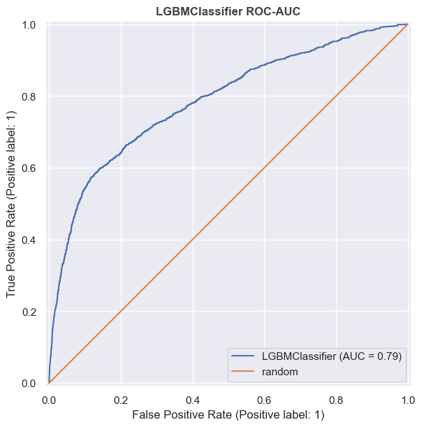

```python
### plotting the AUC curve for LGBM model

fig, ax = plt.subplots(figsize=(8,6), layout='constrained')

RocCurveDisplay.from_estimator(
    grid_lgbm.best_estimator_,
    X_test,
    y_test,
    ax=ax,
    name=f'LGBMClassifier'
    )

ax.plot([0,1],[0,1], label='random')
ax.set_title('LGBMClassifier ROC-AUC')
ax.grid(True)
plt.legend(loc='lower right')
plt.show()
```

[output not shown]

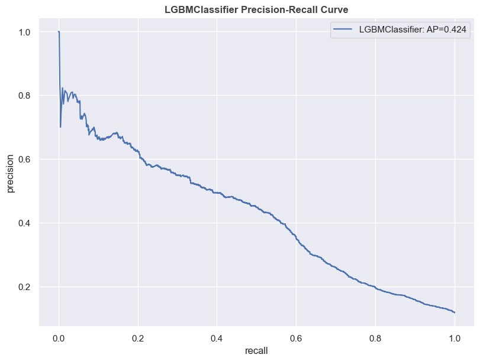

```python
### plotting the precision recall curve for LGBM

fig, ax = plt.subplots(figsize=(8,6), layout='constrained')

y_scores = grid_lgbm.best_estimator_.predict_proba(X_test)[:, 1]

precision, recall, thresholds = precision_recall_curve(y_test, y_scores)
average_precision = average_precision_score(y_test, y_scores)

ax.plot(recall, precision, label=f'LGBMClassifier: AP={average_precision:.3f}')

ax.set_xlabel('recall')
ax.set_ylabel('precision')
ax.set_title('LGBMClassifier Precision-Recall Curve')
ax.grid(True)
plt.legend()
plt.show()
```

[output not shown]

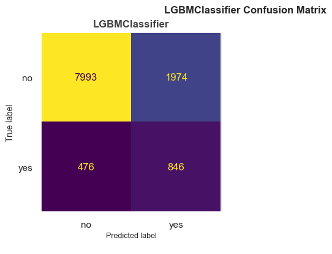

```python
# Confusion matrix display for LGBM
lgbm_model = {'LGBMClassifier': grid_lgbm.best_estimator_}

LGBM_model_results = plot_confusion_matrix(lgbm_model, X_test, y_test, title='LGBMClassifier')
```

```python
display('LGBMClassifier Metrics Results')
pd.DataFrame(LGBM_model_results)
```

```
'LGBMClassifier Metrics Results'
```

|  | LGBMClassifier |
| --- | --- |
| AUC | 0.786 |
| Average_precision | 0.424 |
| recall | 0.640 |
| fi_score | 0.408 |
| precision_score | 0.300 |

```python
## Pridicting X test with LGBMClassifier model

predicted_class = grid_lgbm.best_estimator_.predict(X_test)
```

[output not shown]

```python
print("LGBMClassifier accuracy score: {} ".format(round(accuracy_score(y_test, predicted_class), 3)))
```

```
LGBMClassifier accuracy score: 0.883
```

#### Summary LGBM

The LGBMClassifier shows some improvement in modelling the data compared to the SMOTE models and class_weight models.

**AUC/ Precision-recall/ Confusion Matrix** The auc score improved to 0.79 and with better precision-recall of 0.424 (4x better than random guess). Also, the confusion matrix display shows that there is better improvement at predicting the positive class compared to all other models.

Also, the prediction accuracy for the test data was 88% percent which is consistent with the class_weight voting classifier.

Finally, the metrics score for the LGBM outperformed all the other models tried so far for the dataset

### Final Model Recommendation

The final model shall be chosen by the metrics performance comparison

```python
## Comparing all the scoring metrics for all models
new_columns = pd.MultiIndex.from_tuples([
    ('Class_weight', 'LogisticRegression'),
    ('Class_weight', 'SGDClassifier'),
    ('Class_weight', 'KNeighborsClassifier'),
    ('Class_weight', 'VotingClassifier'),
    ('SMOTE', 'LogisticRegression'),
    ('SMOTE', 'SGDClassifier'),
    ('SMOTE', 'KNeighborsClassifier'),
    ('SMOTE', 'VotingClassifier'),
    ('LGBM_model', 'LGBMClassifier')

])
Results_Summary = pd.concat([pd.DataFrame(Class_weight_model), pd.DataFrame(SMOTE_weight_models), pd.DataFrame(LGBM_model_results)], axis=1)
Results_Summary.columns = new_columns
Results_Summary
```

|  | Class_weight LogisticRegression | Class_weight SGDClassifier | Class_weight KNeighborsClassifier | Class_weight VotingClassifier | SMOTE LogisticRegression | SMOTE SGDClassifier | SMOTE KNeighborsClassifier | SMOTE VotingClassifier | LGBM_model LGBMClassifier |
| --- | --- | --- | --- | --- | --- | --- | --- | --- | --- |
| AUC | 0.704 | 0.715 | 0.690 | 0.741 | 0.702 | 0.711 | 0.698 | 0.738 | 0.786 |
| Average_precision | 0.326 | 0.341 | 0.287 | 0.376 | 0.327 | 0.339 | 0.238 | 0.363 | 0.424 |
| recall | 0.427 | 0.437 | 0.415 | 0.535 | 0.406 | 0.415 | 0.303 | 0.507 | 0.640 |
| fi_score | 0.353 | 0.356 | 0.348 | 0.384 | 0.345 | 0.348 | 0.302 | 0.377 | 0.408 |
| precision_score | 0.300 | 0.300 | 0.300 | 0.300 | 0.300 | 0.300 | 0.300 | 0.300 | 0.300 |

Based on all the metrics and curves for the class_weight, SMOTE-weight and LGBM models, the best performing model in all the scoring metrics was LGBMClassifier Model. Therefore the recommended model for predicting customer term deposit subcription is the cross validated `LGBMClassifier` model

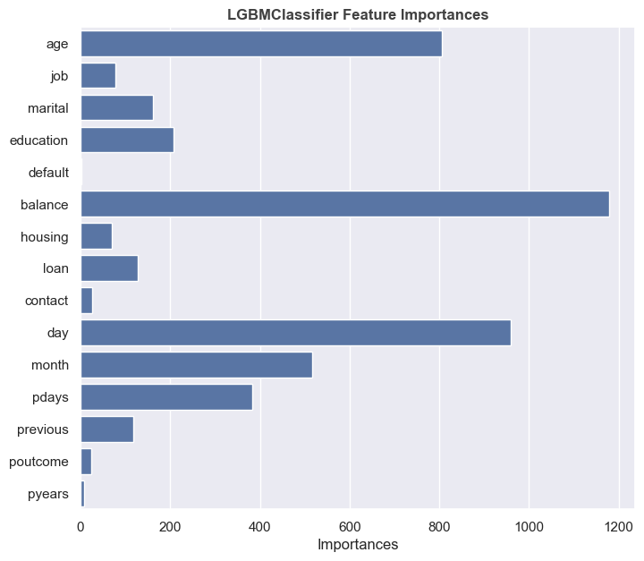

```python
## Plotting feature importances of LGBMClassifier model
fig, ax = plt.subplots(figsize=(8, 7))
sns.barplot(x=grid_lgbm.best_estimator_.feature_importances_,
            y = grid_lgbm.best_estimator_.feature_name_,
            ax=ax)
ax.set_title('LGBMClassifier Feature Importances')
ax.set_ylabel('')
ax.set_xlabel('Importances')
plt.show()
```

##### Best Model Summary of Importances

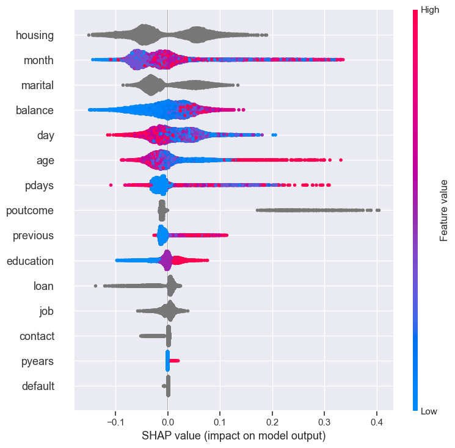

```python
## Using SHAP to plot the feature importances
import shap
explainer = shap.Explainer(grid_lgbm.best_estimator_)
shap_values = explainer(X_test)
shap.summary_plot(shap_values, X_test,)
```

The SHAP plot for the predictions reveal that housing, month, marital, balance are the top four features impacting the predictions. Having a housing loan (yes) means likely to decline a term deposit. Depending on the month, one may subscribe to term deposit. Marital has mixed influence on term deposit subscription. Finally, having a big balance means one can also subscribe to term deposit.

Then the least features impacting the predictions are default, pyears, contact and job.

## Conclusion

In this notebook, I have taken a bank marketing campaign data for term deposit subscription and modelled potential client responses. The data was an inbalance dataset showing that only about 11% of the total clients contacted responded positively to the subscription service.

In the modelling, i have compared three different levels of modelling. First was the sklearn class_weight estimators without oversampling of the positive class and relying on the class weight parameter. The second was over_sampling with SMOTE and modelling with Sklearn estimators. The last was using LightGBM classifier to model the data. The models performances were compared and evaluated using ROC-AUC scores, Precision-Recall scores and confusion matrix display. All models struggled to predict the positive classes with varying scores. The best performing models were cross validated and results showed that the models were able to learn the patterns in the data.

Overall, it was found that the best performing model with higher AUC score, Average precision score, recall, f1_score and accuracy was the LGBMClassifier.